# Case Study 3: Galeries Lafayette

UNIGE - GSEM - Advanced Data-Driven Decision Making

2023-04-30

Abstract

Identify the key drivers of brand equity for Galeries Lafayette based on a questionnaire mailed to 5000 customers and returned by 600 of them

> *This analysis was prepared by Francisco Arrieta and Jonathan Edwards.*

# 1 Setup

```r
# options(scipen=999) #prevent scientific notation
# options(scipen=-999) #encourage scientific notation
options(scipen=0) #encourage scientific notation neutral?
```

```r
# kable table layout options
# do not display NAs and only 2 digits
opts <- options(knitr.kable.NA = '') #knitr.table.format = "latex"

# define table styling options
stable <- function(data, digits = 2) {
  knitr::kable(data, digits=digits) |>
    # kable_styling(c("striped", "condensed"))
    kable_paper(full_width = F)
}
```

## 1.1 libraries

```r
# modelling
library(psych) #factor analysis tools (PAF PAF)
library(lavaan) #causal analysis
library(lm.beta) # add standarized regression coeffs

# stats
library(nortest) #Kolmogorov-Smirnov-Test
library(corrplot) #correlation matrix plot
library(olsrr)  #VIF and Tolerance Values
library(pastecs) # provides function stat.desc
library(REdaS) #Bartelett's Test

# plotting & formatting
library(ggplot2) #better graphs
library(patchwork) # provides wrap_plots for multiplotting
# library(gridExtra) #provides multiplotting functionality
# library(ggpubr) #provides ggarrange for multiplotting (patchwork better though)
library(semPlot) #for visualization of path diagrams (SEM)
library(lavaanPlot) #for visualization of path diagrams (SEM)
# library(rcompanion)   #Histogram and Normal Curve
library(kableExtra) #makes nice tables

# generic
library(dplyr) #useful data manip functions like arrange, distinct, rename etc included in fpp3
library(stringr) # provides string manip functions like str_split_fixed
library(Hmisc) #describe function that describes features of dataframes
library(data.table) # creating and manipulating datatables
library(knitr) #rmarkdown tools not sure why useful
library(parameters) #get model outputs in table form (good for making tabs)
```

## 1.2 Load data

```r
survey <- read.csv("Case Study III_Structural Equation Modeling.csv")
labels <- read.csv("Variables and Labels_Galeries Lafayette.csv")

dim(survey)
```

```
## [1] 553  45
```

```r
# head(labels)
```

## 1.3 labels

```r
#Make labels more readable
#create copy of label column without variable code
labels["Category"] <- sub("[^-]*\\s-","",labels[["Label"]])
# labels["Category"] <- sub(".*\\s-","",labels[["Label"]])
# labels

#split this new column (category) into category and short label
labels[c("Category","Label_short")] <- str_split_fixed(labels[["Category"]],"\\?\\s\\s|\\s-", n=2)
# labels[20:25,c("Category","Label_short")]
labels[,c("Variable","Category","Label_short")] |>
  stable()
```

| Variable | Category | Label_short |
| --- | --- | --- |
| Im1 | What do GLB represent from your point of view | Large Assortment |
| Im2 | What do GLB represent from your point of view | Assortment Variety |
| Im3 | What do GLB represent from your point of view | Artistic Decoration of Sales Area |
| Im4 | What do GLB represent from your point of view | Creative Decoration of Sales Area |
| Im5 | What do GLB represent from your point of view | Appealing Arrangement of Shop Windows |
| Im6 | What do GLB represent from your point of view | France |
| Im7 | What do GLB represent from your point of view | French Savoir-vivre |
| Im8 | What do GLB represent from your point of view | Expertise in French Traditional Cuisine |
| Im9 | What do GLB represent from your point of view | French Fashion |
| Im10 | What do GLB represent from your point of view | Gourmet Food |
| Im11 | What do GLB represent from your point of view | High-quality Cosmetics |
| Im12 | What do GLB represent from your point of view | Luxury brands |
| Im13 | What do GLB represent from your point of view | Up tp date Designer Brands |
| Im14 | What do GLB represent from your point of view | Gourmet specialities |
| Im15 | What do GLB represent from your point of view | Professional Selection of Brands |
| Im16 | What do GLB represent from your point of view | Professional Appearance Towards Customers |
| Im17 | What do GLB represent from your point of view | Are Trendy |
| Im18 | What do GLB represent from your point of view | Are Hip |
| Im19 | What do GLB represent from your point of view | Professional Organization |
| Im20 | What do GLB represent from your point of view | Relaxing Shopping |
| Im21 | What do GLB represent from your point of view | A Great Place to Stroll |
| Im22 | What do GLB represent from your point of view | Intimate Shop Atmosphere |
| C_CR1 | CO-CREATION | I would like to participate in an expert-workshop to improve the assortment of Galeries Lafayette Berlin. |
| C_CR2 | CO-CREATION | I would be available to take part in another survey at Galeries Lafayette Berlin. |
| C_CR3 | CO-CREATION | I would like to become a member of a customer group whose opinion is obtained for new products and major changes. |
| C_CR4 | CO-CREATION | I would like to participate in planning and designing special events (e.g. fashion show, introduction of new car models) if asked. |
| C_REP1 | REPURCHASE | I will continue to be a loyal customer of Galeries Lafayette Berlin. |
| C_REP2 | REPURCHASE | I intend to shop at Galeries Lafayette Berlin in the future. |
| C_REP3 | REPURCAHSE | I will surely visit Galeries Lafayette Berlin in the future. |
| COM_A1 | AFFECTIVE COMMITMENT | How strongly are you attached to Galeries Lafayette Berlin? |
| COM_A2 | AFFECTIVE COMMITMENT | How strongly are you emotionally connected to Galeries Lafayette Berlin? |
| COM_A3 | AFFECTIVE COMMITMENT | As a customer I feel (close) attached to GL |
| COM_A4 | AFFECTIVE COMMITMENT | feel a strong emotional bond toward GLB |
| SAT_1 | SATISFACTION | I am very satisfied with Galeries Lafayette Berlin. |
| SAT_2 | SATISFACTION | Overall, I am very satisfied with Galeries Lafayette Berlin. |
| SAT_3 | SATISFACTION | How satisfied are you with Galeries Lafayette Berlin? |
| SAT_P1 | SATISFACTION EMPLOYEES | The employees are capable and professional. |
| SAT_P2 | SATISFACTION EMPLOYEES | The employees know best about their products. |
| SAT_P3 | SATISFACTION EMPLOYEES | The employees are well-informed. |
| SAT_P4 | SATISFACTION EMPLOYEES | The employees are always helpful. |
| SAT_P5 | SATISFACTION EMPLOYEES | The employees are willing to respond to my questions in detail. |
| SAT_P6 | SATISFACTION EMPLOYEES | The employees are friendly. |
| TRU_1 | TRUST | I have the feeling that I can completely rely on GL. |
| TRU_2 | TRUST | GLB will always be honest and trustful with me. |
| TRU_3 | TRUST | GL will treat me always fair as a customer |

## 1.4 Clean and handle missing data

```r
# # omit all unanswered
# filter_all(survey, all_vars(. != 999))
# filter_all(survey, any_vars(. %in% c(999)))
#
# filter_all(select(survey,1:22,"SAT_1"), all_vars(. != 999))
# filter_all(select(survey,1:22,"SAT_1"), any_vars(. %in% c(999)))
#
# filter_all(data_img_EFA, all_vars(. != 999))
# filter_all(ges, any_vars(. %in% c(999)))
```

```r
# delete variables unused in analysis (see case study instructions):
survey <- survey |> select(-c("C_CR2", "SAT_P1", "SAT_P2", "SAT_P3", "SAT_P4", "SAT_P5", "SAT_P6", "TRU_1", "TRU_2", "TRU_3"))

# replace missing data (999) with NA
survey <- data.frame(sapply(survey,function(x) ifelse((x==999),NA,as.numeric(x))))
```

## 1.5 Explore Data

# 2 Dimensions by which Galeries Lafayette is perceived

## 2.1 ROUND 1: Exploratory factor analysis

### 2.1.1 Variable selection for EFA

```r
# excluded image variables (in the first round of EFA we don't exclude any image variables...)
exclude=c()

# the full survey data (includes dependent and independent variables) with excluded image variables (in this first round of EFA we don't exclude anything)
survey_excl_img <- survey |> select(-exclude)

# the data we will use for EFA (images)
data_img_EFA <- survey_excl_img[1:(22-length(exclude))]
```

### 2.1.2 handle missing data

```r
# delete missing data (delete listwise)
data_img_EFA <- na.omit(data_img_EFA)

dim(survey)
```

```
## [1] 553  35
```

```r
dim(survey_excl_img)
```

```
## [1] 553  35
```

```r
dim(data_img_EFA)
```

```
## [1] 385  22
```

### 2.1.3 Check adequacy of correlation Matrix

#### 2.1.3.1 correlation matrix

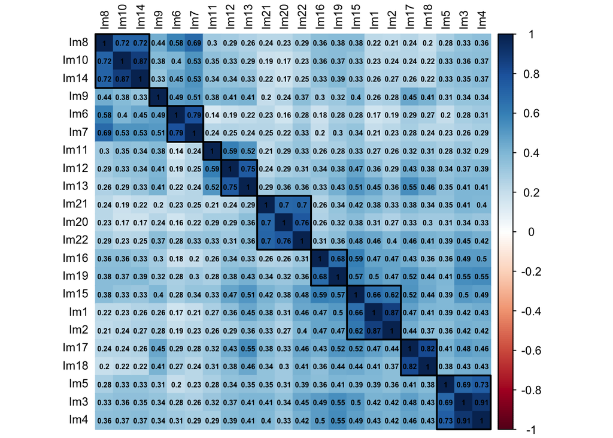

```r
#plot correlation matrix adjusting parameters to see previously identified groupings
corr_matrix <- cor(data_img_EFA)
corrplot(as.matrix(corr_matrix),
         method = "color", #col = c("white","white","white","white","white", "lightgrey", "darkgrey", "black"),
         order = "hclust", addrect = 10, rect.col="black", # rect.col="red",
         addCoef.col = 'black', number.cex = .5,
         tl.col ="black",
         tl.cex = 0.80,
         )
```

#### 2.1.3.2 Bartlett’s Test

```r
bart_spher(data_img_EFA)
```

```
##  Bartlett's Test of Sphericity
##
## Call: bart_spher(x = data_img_EFA)
##
##      X2 = 6451.238
##      df = 231
## p-value < 2.22e-16
```

The Bartlett Test tests the hypothesis that the sample originates from a population, where all variables are uncorrelated. This would not be good for factor analysis, we want this hypothesis to be rejected meaning p-value < 5%.

In our case we see that it is indeed rejected and that the data is not uncorrelated.

#### 2.1.3.3 KMO

```r
KMOTEST=KMOS(data_img_EFA)
print(KMOTEST, sort=T)
```

```
##
## Kaiser-Meyer-Olkin Statistics
##
## Call: KMOS(x = data_img_EFA)
##
## Measures of Sampling Adequacy (MSA):
##       Im2       Im6       Im1      Im20      Im14      Im10       Im7       Im4
## 0.8224640 0.8224827 0.8244624 0.8266391 0.8267452 0.8285789 0.8448231 0.8542604
##      Im18       Im3      Im17      Im13      Im12      Im22      Im16      Im11
## 0.8550678 0.8640362 0.8644991 0.8722220 0.8789413 0.8793157 0.9092200 0.9113882
##      Im21       Im8       Im9      Im19       Im5      Im15
## 0.9149654 0.9300079 0.9380091 0.9400714 0.9546668 0.9647563
##
## KMO-Criterion: 0.8770975
```

The KMO of 0.8770975 is above 0.6 which indicates the data is well suited for factor anlysis.

#### 2.1.3.4 Anti-image Correlation

```r
MSA_list <- data.table("Item"=names(KMOTEST$MSA), "MSA"=as.numeric(KMOTEST$MSA))

# Sort table
MSA_list<- MSA_list |>
  setorder(cols = "MSA")

# Display table
MSA_list |>
  stable() |>
  row_spec(which(MSA_list[,2]<0.5), bold = T, color = "white", background = "#78BE20")
```

| Item | MSA |
| --- | --- |
| Im2 | 0.82 |
| Im6 | 0.82 |
| Im1 | 0.82 |
| Im20 | 0.83 |
| Im14 | 0.83 |
| Im10 | 0.83 |
| Im7 | 0.84 |
| Im4 | 0.85 |
| Im18 | 0.86 |
| Im3 | 0.86 |
| Im17 | 0.86 |
| Im13 | 0.87 |
| Im12 | 0.88 |
| Im22 | 0.88 |
| Im16 | 0.91 |
| Im11 | 0.91 |
| Im21 | 0.91 |
| Im8 | 0.93 |
| Im9 | 0.94 |
| Im19 | 0.94 |
| Im5 | 0.95 |
| Im15 | 0.96 |

Variables with MSA values above 0.5 are suited for factor analysis. Presence of items with low MSA’s (<0.5) could also indicate that an important topic hasn’t been well covered in the questionnaire.

All variables have MSA above 0.5

### 2.1.4 Select method: PAF

#### 2.1.4.1 Extract factors

```r
EFA_PAF0 <- psych::fa(data_img_EFA, rotate="varimax", scores=TRUE)
# note: by default number of factors = 1 if it is not specified
```

##### 2.1.4.1.1 Scree plot

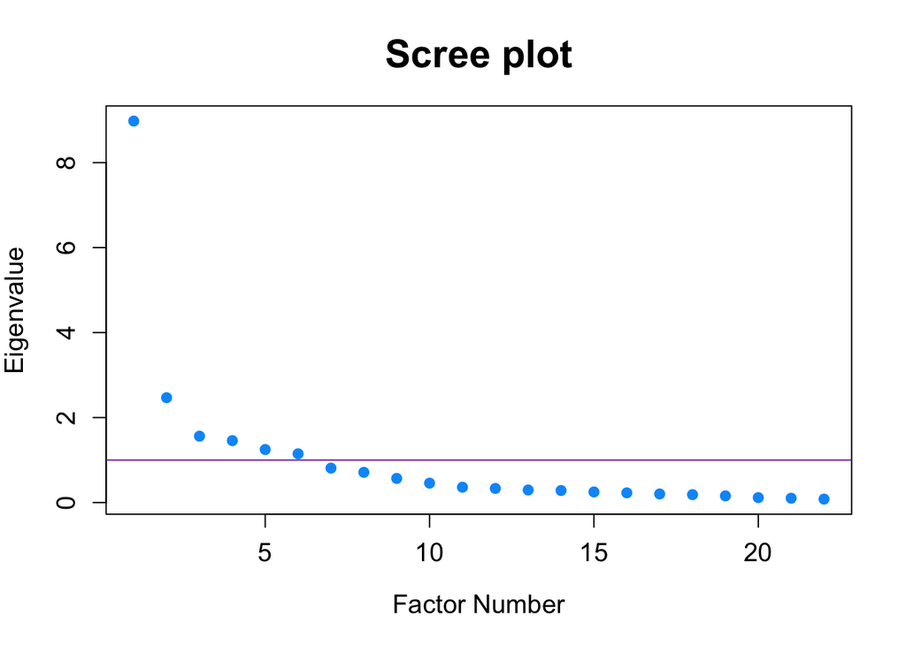

```r
#display Scree-plot
plot(EFA_PAF0$e.values,xlab="Factor Number",
     ylab="Eigenvalue",
     main="Scree plot",
     cex.lab=1.2,
     cex.axis=1.2,
     cex.main=1.8,
     col = "#0099F8",
     pch = 19)
abline(h=1, col = "#7F35B2")
```

##### 2.1.4.1.2 Kaiser Criterion

```r
EFA_PAF0_kaiser_nb <- length(which(EFA_PAF0$e.values > 1))
EFA_PAF0_kaiser_nb
```

```
## [1] 6
```

The Kaiser criterion suggests we should retain factors with eigenvalues bigger than 1.

There are 6 factors satisfying this condition.

##### 2.1.4.1.3 Total Variance Explained

```r
#calculate total variance (does not change if number of factors change)
EFA_PAF0_EigenValue <- EFA_PAF0$e.values
EFA_PAF0_Variance <- EFA_PAF0_EigenValue / ncol(data_img_EFA) * 100
EFA_PAF0_SumVariance <- cumsum(EFA_PAF0_EigenValue / ncol(data_img_EFA))
EFA_PAF0_Total_Variance_Explained <- cbind("Factor number"=
                                            seq(1, length.out=length(EFA_PAF0_EigenValue[EFA_PAF0_EigenValue>0])),
                                          EigenValue = EFA_PAF0_EigenValue[EFA_PAF0_EigenValue>0],
                                          Variance = EFA_PAF0_Variance[EFA_PAF0_EigenValue>0],
                                          Total_Variance = EFA_PAF0_SumVariance[EFA_PAF0_EigenValue>0])
#display table
EFA_PAF0_Total_Variance_Explained |>
  stable()
```

| Factor number | EigenValue | Variance | Total_Variance |
| --- | --- | --- | --- |
| 1 | 8.98 | 40.81 | 0.41 |
| 2 | 2.47 | 11.21 | 0.52 |
| 3 | 1.56 | 7.10 | 0.59 |
| 4 | 1.46 | 6.62 | 0.66 |
| 5 | 1.25 | 5.67 | 0.71 |
| 6 | 1.15 | 5.22 | 0.77 |
| 7 | 0.81 | 3.68 | 0.80 |
| 8 | 0.71 | 3.23 | 0.84 |
| 9 | 0.57 | 2.58 | 0.86 |
| 10 | 0.46 | 2.08 | 0.88 |
| 11 | 0.36 | 1.64 | 0.90 |
| 12 | 0.33 | 1.51 | 0.91 |
| 13 | 0.29 | 1.34 | 0.93 |
| 14 | 0.28 | 1.29 | 0.94 |
| 15 | 0.25 | 1.13 | 0.95 |
| 16 | 0.23 | 1.04 | 0.96 |
| 17 | 0.20 | 0.92 | 0.97 |
| 18 | 0.19 | 0.85 | 0.98 |
| 19 | 0.16 | 0.72 | 0.99 |
| 20 | 0.12 | 0.53 | 0.99 |
| 21 | 0.10 | 0.46 | 1.00 |
| 22 | 0.08 | 0.37 | 1.00 |

With 6 factors we would explain 76.6310791% of total variance.

With 7 factors we would explain 80.3133487% of total variance.

```r
# test eigenvalue calculation
factorloadings = EFA_PAF0$loadings[,1] # loadings 1st factor (default is nfactors = 1)
Eigenvalue = sum(factorloadings^2)
Eigenvalue
```

```
## [1] 8.377985
```

#### 2.1.4.2 Determine number of factors to retain

```r
# select nb of factors to test
nf = c(5,6,7,8)
```

#### 2.1.4.3 PAF orthogonal Varimax with n factors

```r
# perform multiple PAFs one for each factor number in selection
EFA_PAFn = list()

i=1
for (n in nf) {
  # EFA_PAFn[[i]] <- n
  EFA_PAFn[[i]] <- psych::fa(data_img_EFA, rotate="varimax", scores=TRUE, nfactors = n)
  i=i+1
}
names(EFA_PAFn) <- nf
```

##### 2.1.4.3.1 Communalities

```r
#communalities for all selected number of factors

for (i in 1:length(nf)) {

  cat("###### Number of factors =", nf[[i]], "{.unnumbered}" ,"\n")

    EFA_PAFn_communalities <- data.table("Item"=names(EFA_PAFn[[i]]$communality),
                             "Communality"=as.numeric(EFA_PAFn[[i]]$communality))

    # Sort table
    EFA_PAFn_communalities <- EFA_PAFn_communalities |>
      setorder(cols = "Communality")

    # Display table
    kbl <- EFA_PAFn_communalities |>
              stable() |>
              row_spec(which(EFA_PAFn_communalities[,1]<.3), bold = T, color = "white", background = "#78BE20")

    print(kbl)
    cat("\n\n")

    # test communality calculation
    variableloading = EFA_PAFn[[i]]$loadings["Im9",] # loadings 1st variable
    communality = sum(variableloading^2)
    print(paste0("Communality for Im9 =", communality))
    cat("\n")

}
```

###### Number of factors = 5

| Item | Communality |
| --- | --- |
| Im9 | 0.41 |
| Im11 | 0.41 |
| Im18 | 0.43 |
| Im16 | 0.46 |
| Im6 | 0.50 |
| Im19 | 0.53 |
| Im17 | 0.54 |
| Im5 | 0.55 |
| Im15 | 0.63 |
| Im21 | 0.65 |
| Im14 | 0.66 |
| Im10 | 0.66 |
| Im7 | 0.69 |
| Im20 | 0.69 |
| Im12 | 0.71 |
| Im13 | 0.72 |
| Im2 | 0.76 |
| Im8 | 0.76 |
| Im22 | 0.81 |
| Im1 | 0.82 |
| Im3 | 0.86 |
| Im4 | 0.92 |

[1] “Communality for Im9 =0.405600881872799”

###### Number of factors = 6

| Item | Communality |
| --- | --- |
| Im11 | 0.45 |
| Im9 | 0.46 |
| Im16 | 0.47 |
| Im19 | 0.52 |
| Im5 | 0.55 |
| Im18 | 0.57 |
| Im15 | 0.63 |
| Im21 | 0.65 |
| Im17 | 0.70 |
| Im13 | 0.70 |
| Im6 | 0.71 |
| Im12 | 0.73 |
| Im8 | 0.74 |
| Im14 | 0.76 |
| Im2 | 0.76 |
| Im10 | 0.78 |
| Im7 | 0.78 |
| Im20 | 0.79 |
| Im22 | 0.79 |
| Im1 | 0.84 |
| Im3 | 0.85 |
| Im4 | 0.92 |

[1] “Communality for Im9 =0.463399199002637”

###### Number of factors = 7

| Item | Communality |
| --- | --- |
| Im11 | 0.44 |
| Im9 | 0.46 |
| Im16 | 0.47 |
| Im19 | 0.53 |
| Im5 | 0.54 |
| Im15 | 0.63 |
| Im21 | 0.65 |
| Im13 | 0.70 |
| Im18 | 0.71 |
| Im8 | 0.72 |
| Im6 | 0.76 |
| Im2 | 0.78 |
| Im22 | 0.79 |
| Im20 | 0.79 |
| Im14 | 0.81 |
| Im12 | 0.83 |
| Im7 | 0.85 |
| Im1 | 0.86 |
| Im3 | 0.86 |
| Im10 | 0.89 |
| Im17 | 0.95 |
| Im4 | 0.97 |

[1] “Communality for Im9 =0.455673655610471”

###### Number of factors = 8

| Item | Communality |
| --- | --- |
| Im11 | 0.45 |
| Im9 | 0.46 |
| Im5 | 0.58 |
| Im19 | 0.62 |
| Im15 | 0.65 |
| Im21 | 0.65 |
| Im13 | 0.70 |
| Im8 | 0.72 |
| Im18 | 0.74 |
| Im6 | 0.76 |
| Im22 | 0.78 |
| Im16 | 0.80 |
| Im2 | 0.81 |
| Im20 | 0.81 |
| Im12 | 0.84 |
| Im7 | 0.85 |
| Im14 | 0.85 |
| Im3 | 0.86 |
| Im10 | 0.90 |
| Im17 | 0.93 |
| Im1 | 0.94 |
| Im4 | 0.97 |

[1] “Communality for Im9 =0.455554069181416”

Typically we should think about excluding variables with communalities below 0.3.

Based on the above, no variable should be excluded.

##### 2.1.4.3.2 Factor loadings

```r
# loadings for all selected number of factors

for (i in 1:length(nf)) {

cat("###### Number of factors =", nf[[i]], "{.unnumbered}" ,"\n")

      # print(EFA_PAFn[[i]]$loadings, cutoff=0.3)
      # print(print_html(model_parameters(EFA_PAFn[[i]], loadings=T, threshold = 0.3, summary=T)))
     kbl <- model_parameters(EFA_PAFn[[i]], loadings=T, threshold = 0.3, summary=T) |>
        stable()
     print(kbl)

cat("\n\n")
}
```

###### Number of factors = 5

| Variable | MR2 | MR5 | MR4 | MR1 | MR3 | Complexity | Uniqueness |
| --- | --- | --- | --- | --- | --- | --- | --- |
| Im1 |  | 0.85 |  |  |  | 1.31 | 0.18 |
| Im2 |  | 0.83 |  |  |  | 1.23 | 0.24 |
| Im3 |  |  |  | 0.83 |  | 1.55 | 0.14 |
| Im4 |  |  |  | 0.87 |  | 1.46 | 0.08 |
| Im5 |  |  |  | 0.64 |  | 1.78 | 0.45 |
| Im6 | 0.67 |  |  |  |  | 1.22 | 0.50 |
| Im7 | 0.79 |  |  |  |  | 1.20 | 0.31 |
| Im8 | 0.84 |  |  |  |  | 1.16 | 0.24 |
| Im9 | 0.43 |  | 0.39 |  |  | 2.76 | 0.59 |
| Im10 | 0.75 |  |  |  |  | 1.37 | 0.34 |
| Im11 |  |  | 0.57 |  |  | 1.56 | 0.59 |
| Im12 |  |  | 0.79 |  |  | 1.27 | 0.29 |
| Im13 |  |  | 0.77 |  |  | 1.43 | 0.28 |
| Im14 | 0.75 |  |  |  |  | 1.37 | 0.34 |
| Im15 |  | 0.60 | 0.33 |  |  | 2.66 | 0.37 |
| Im16 |  | 0.48 |  | 0.37 |  | 2.77 | 0.54 |
| Im17 |  | 0.38 | 0.48 |  |  | 3.44 | 0.46 |
| Im18 |  | 0.31 | 0.43 |  |  | 3.42 | 0.57 |
| Im19 |  | 0.47 |  | 0.40 |  | 3.37 | 0.47 |
| Im20 |  |  |  |  | 0.78 | 1.27 | 0.31 |
| Im21 |  |  |  |  | 0.74 | 1.41 | 0.35 |
| Im22 |  |  |  |  | 0.81 | 1.51 | 0.19 |

###### Number of factors = 6

| Variable | MR2 | MR5 | MR1 | MR4 | MR3 | MR6 | Complexity | Uniqueness |
| --- | --- | --- | --- | --- | --- | --- | --- | --- |
| Im1 |  | 0.86 |  |  |  |  | 1.30 | 0.16 |
| Im2 |  | 0.83 |  |  |  |  | 1.24 | 0.24 |
| Im3 |  |  | 0.83 |  |  |  | 1.51 | 0.15 |
| Im4 |  |  | 0.88 |  |  |  | 1.42 | 0.08 |
| Im5 |  |  | 0.64 |  |  |  | 1.74 | 0.45 |
| Im6 | 0.61 |  |  |  |  | 0.56 | 2.12 | 0.29 |
| Im7 | 0.72 |  |  |  |  | 0.48 | 1.88 | 0.22 |
| Im8 | 0.81 |  |  |  |  |  | 1.25 | 0.26 |
| Im9 | 0.35 |  |  | 0.32 |  | 0.43 | 3.51 | 0.54 |
| Im10 | 0.80 |  |  |  |  |  | 1.42 | 0.22 |
| Im11 |  |  |  | 0.59 |  |  | 1.62 | 0.55 |
| Im12 |  |  |  | 0.79 |  |  | 1.34 | 0.27 |
| Im13 |  |  |  | 0.73 |  |  | 1.66 | 0.30 |
| Im14 | 0.80 |  |  |  |  |  | 1.42 | 0.24 |
| Im15 |  | 0.60 |  |  |  |  | 2.76 | 0.37 |
| Im16 |  | 0.48 | 0.37 |  |  |  | 2.78 | 0.53 |
| Im17 |  | 0.35 | 0.31 | 0.39 |  | 0.54 | 3.66 | 0.30 |
| Im18 |  |  |  | 0.35 |  | 0.50 | 3.48 | 0.43 |
| Im19 |  | 0.46 | 0.40 |  |  |  | 3.45 | 0.48 |
| Im20 |  |  |  |  | 0.84 |  | 1.22 | 0.21 |
| Im21 |  |  |  |  | 0.73 |  | 1.43 | 0.35 |
| Im22 |  |  |  |  | 0.79 |  | 1.60 | 0.21 |

###### Number of factors = 7

| Variable | MR5 | MR1 | MR3 | MR2 | MR4 | MR7 | MR6 | Complexity | Uniqueness |
| --- | --- | --- | --- | --- | --- | --- | --- | --- | --- |
| Im1 | 0.86 |  |  |  |  |  |  | 1.33 | 0.14 |
| Im2 | 0.83 |  |  |  |  |  |  | 1.27 | 0.22 |
| Im3 |  | 0.83 |  |  |  |  |  | 1.56 | 0.14 |
| Im4 |  | 0.90 |  |  |  |  |  | 1.40 | 0.03 |
| Im5 |  | 0.63 |  |  |  |  |  | 1.85 | 0.46 |
| Im6 |  |  |  |  |  | 0.83 |  | 1.25 | 0.24 |
| Im7 |  |  |  | 0.32 |  | 0.84 |  | 1.44 | 0.15 |
| Im8 |  |  |  | 0.63 |  | 0.51 |  | 2.31 | 0.28 |
| Im9 |  |  |  |  | 0.33 | 0.45 |  | 3.45 | 0.54 |
| Im10 |  |  |  | 0.87 |  |  |  | 1.35 | 0.11 |
| Im11 |  |  |  |  | 0.58 |  |  | 1.72 | 0.56 |
| Im12 |  |  |  |  | 0.85 |  |  | 1.30 | 0.17 |
| Im13 |  |  |  |  | 0.72 |  |  | 1.81 | 0.30 |
| Im14 |  |  |  | 0.81 |  |  |  | 1.50 | 0.19 |
| Im15 | 0.59 |  |  |  |  |  |  | 2.97 | 0.37 |
| Im16 | 0.46 | 0.34 |  |  |  |  |  | 3.44 | 0.53 |
| Im17 |  |  |  |  |  |  | 0.84 | 1.76 | 0.05 |
| Im18 |  |  |  |  |  |  | 0.72 | 1.85 | 0.29 |
| Im19 | 0.43 | 0.37 |  |  |  |  |  | 4.25 | 0.47 |
| Im20 |  |  | 0.85 |  |  |  |  | 1.21 | 0.21 |
| Im21 |  |  | 0.73 |  |  |  |  | 1.44 | 0.35 |
| Im22 |  |  | 0.78 |  |  |  |  | 1.62 | 0.21 |

###### Number of factors = 8

| Variable | MR1 | MR3 | MR4 | MR7 | MR2 | MR5 | MR6 | MR8 | Complexity | Uniqueness |
| --- | --- | --- | --- | --- | --- | --- | --- | --- | --- | --- |
| Im1 |  |  |  |  |  | 0.88 |  |  | 1.45 | 0.06 |
| Im2 |  |  |  |  |  | 0.82 |  |  | 1.45 | 0.19 |
| Im3 | 0.81 |  |  |  |  |  |  |  | 1.66 | 0.14 |
| Im4 | 0.89 |  |  |  |  |  |  |  | 1.47 | 0.03 |
| Im5 | 0.65 |  |  |  |  |  |  |  | 1.84 | 0.42 |
| Im6 |  |  |  | 0.83 |  |  |  |  | 1.23 | 0.24 |
| Im7 |  |  |  | 0.84 | 0.30 |  |  |  | 1.40 | 0.15 |
| Im8 |  |  |  | 0.54 | 0.59 |  |  |  | 2.56 | 0.28 |
| Im9 |  |  | 0.33 | 0.46 |  |  |  |  | 3.34 | 0.54 |
| Im10 |  |  |  |  | 0.87 |  |  |  | 1.41 | 0.10 |
| Im11 |  |  | 0.58 |  |  |  |  |  | 1.72 | 0.55 |
| Im12 |  |  | 0.86 |  |  |  |  |  | 1.28 | 0.16 |
| Im13 |  |  | 0.72 |  |  |  |  |  | 1.78 | 0.30 |
| Im14 |  |  |  |  | 0.83 |  |  |  | 1.49 | 0.15 |
| Im15 |  |  |  |  |  | 0.47 |  | 0.39 | 4.81 | 0.35 |
| Im16 |  |  |  |  |  |  |  | 0.77 | 1.78 | 0.20 |
| Im17 |  |  |  |  |  |  | 0.82 |  | 1.82 | 0.07 |
| Im18 |  |  |  |  |  |  | 0.74 |  | 1.76 | 0.26 |
| Im19 | 0.30 |  |  |  |  |  |  | 0.54 | 3.68 | 0.38 |
| Im20 |  | 0.86 |  |  |  |  |  |  | 1.20 | 0.19 |
| Im21 |  | 0.73 |  |  |  |  |  |  | 1.44 | 0.35 |
| Im22 |  | 0.78 |  |  |  |  |  |  | 1.63 | 0.22 |

Based on the above we will prefer the **7 factor solution** but we will no doubt have to exclude some variables.

Similarly Im17 and Im18 are highly correlated we might want to eliminate Im18 which has the lowest communality of the two, but they have adequately high loadings in the 7 factor solution so not a priority.

We might also exclude Im9 and Im15 as their communality is on the lower end and their loadings are spread out and quite weak. Also Im9 is problematic in both the 6 and 7 factor solution

Thurstone simple structure criteria:

- Each row (variable) of the factor pattern matrix should have at least one zero
- Each column (factor) should have at least r zero elements, and the zeros for one factor should be unique from the zeros for the other factors
- For every pair of columns (factors), there should be at least r variables with a zero coefficient in one column and a non-zero coefficient in the other
- When r > 3 every pair of columns (factors), should contain a large proportion of variables with zeros in both columns
- For every pair of columns (factors), there should be only a small proportion of variables with non-zeros in both columns

#### 2.1.4.4 PAF oblique Promax with n factors

```r
# perform multiple PAFs one for each factor number in selection
EFA_PAFn_obl = list()

i=1
for (n in nf) {
  # EFA_PAFn_obl[[i]] <- n
  EFA_PAFn_obl[[i]] <- psych::fa(data_img_EFA, rotate="promax", scores=TRUE, nfactors = n)
  i=i+1
}
names(EFA_PAFn_obl) <- nf

length(EFA_PAFn_obl)
```

```
## [1] 4
```

##### 2.1.4.4.1 Communalities

```r
#communalities for all selected number of factors

for (i in 1:length(nf)) {

  cat("###### Number of factors =", nf[[i]], "{.unnumbered}" ,"\n")

    EFA_PAFn_obl_communalities <- data.table("Item"=names(EFA_PAFn_obl[[i]]$communality),
                             "Communality"=as.numeric(EFA_PAFn_obl[[i]]$communality))

    # Sort table
    EFA_PAFn_obl_communalities <- EFA_PAFn_obl_communalities |>
      setorder(cols = "Communality")

    # Display table
    kbl <- EFA_PAFn_obl_communalities |>
              stable() |>
              row_spec(which(EFA_PAFn_obl_communalities[,1]<.3), bold = T, color = "white", background = "#78BE20")

    print(kbl)
    cat("\n\n")

    # test communality calculation
    variableloading = EFA_PAFn_obl[[i]]$loadings["Im9",] # loadings 1st variable
    communality = sum(variableloading^2)
    print(paste0("Communality for Im9 =", communality))
    cat("\n")

}
```

###### Number of factors = 5

| Item | Communality |
| --- | --- |
| Im9 | 0.41 |
| Im11 | 0.41 |
| Im18 | 0.43 |
| Im16 | 0.46 |
| Im6 | 0.50 |
| Im19 | 0.53 |
| Im17 | 0.54 |
| Im5 | 0.55 |
| Im15 | 0.63 |
| Im21 | 0.65 |
| Im14 | 0.66 |
| Im10 | 0.66 |
| Im7 | 0.69 |
| Im20 | 0.69 |
| Im12 | 0.71 |
| Im13 | 0.72 |
| Im2 | 0.76 |
| Im8 | 0.76 |
| Im22 | 0.81 |
| Im1 | 0.82 |
| Im3 | 0.86 |
| Im4 | 0.92 |

[1] “Communality for Im9 =0.272947652560888”

###### Number of factors = 6

| Item | Communality |
| --- | --- |
| Im11 | 0.45 |
| Im9 | 0.46 |
| Im16 | 0.47 |
| Im19 | 0.52 |
| Im5 | 0.55 |
| Im18 | 0.57 |
| Im15 | 0.63 |
| Im21 | 0.65 |
| Im17 | 0.70 |
| Im13 | 0.70 |
| Im6 | 0.71 |
| Im12 | 0.73 |
| Im8 | 0.74 |
| Im14 | 0.76 |
| Im2 | 0.76 |
| Im10 | 0.78 |
| Im7 | 0.78 |
| Im20 | 0.79 |
| Im22 | 0.79 |
| Im1 | 0.84 |
| Im3 | 0.85 |
| Im4 | 0.92 |

[1] “Communality for Im9 =0.339338697735652”

###### Number of factors = 7

| Item | Communality |
| --- | --- |
| Im11 | 0.44 |
| Im9 | 0.46 |
| Im16 | 0.47 |
| Im19 | 0.53 |
| Im5 | 0.54 |
| Im15 | 0.63 |
| Im21 | 0.65 |
| Im13 | 0.70 |
| Im18 | 0.71 |
| Im8 | 0.72 |
| Im6 | 0.76 |
| Im2 | 0.78 |
| Im22 | 0.79 |
| Im20 | 0.79 |
| Im14 | 0.81 |
| Im12 | 0.83 |
| Im7 | 0.85 |
| Im1 | 0.86 |
| Im3 | 0.86 |
| Im10 | 0.89 |
| Im17 | 0.95 |
| Im4 | 0.97 |

[1] “Communality for Im9 =0.279736181915467”

###### Number of factors = 8

| Item | Communality |
| --- | --- |
| Im11 | 0.45 |
| Im9 | 0.46 |
| Im5 | 0.58 |
| Im19 | 0.62 |
| Im15 | 0.65 |
| Im21 | 0.65 |
| Im13 | 0.70 |
| Im8 | 0.72 |
| Im18 | 0.74 |
| Im6 | 0.76 |
| Im22 | 0.78 |
| Im16 | 0.80 |
| Im2 | 0.81 |
| Im20 | 0.81 |
| Im12 | 0.84 |
| Im7 | 0.85 |
| Im14 | 0.85 |
| Im3 | 0.86 |
| Im10 | 0.90 |
| Im17 | 0.93 |
| Im1 | 0.94 |
| Im4 | 0.97 |

[1] “Communality for Im9 =0.302814913694533”

##### 2.1.4.4.2 Factor loadings

```r
# loadings for all selected number of factors

for (i in 1:length(nf)) {

cat("###### Number of factors =", nf[[i]], "{.unnumbered}" ,"\n")

      # print(EFA_PAFn_obl[[i]]$loadings, cutoff=0.3)
      # print(print_html(model_parameters(EFA_PAFn_obl[[i]], loadings=T, threshold = 0.3, summary=T)))
     kbl <- model_parameters(EFA_PAFn_obl[[i]], loadings=T, threshold = 0.3, summary=T) |>
        stable()
     print(kbl)

cat("\n\n")
}
```

###### Number of factors = 5

| Variable | MR2 | MR5 | MR1 | MR4 | MR3 | Complexity | Uniqueness |
| --- | --- | --- | --- | --- | --- | --- | --- |
| Im1 |  | 1.07 |  |  |  | 1.06 | 0.18 |
| Im2 |  | 1.07 |  |  |  | 1.07 | 0.24 |
| Im3 |  |  | 1.00 |  |  | 1.03 | 0.14 |
| Im4 |  |  | 1.07 |  |  | 1.03 | 0.08 |
| Im5 |  |  | 0.75 |  |  | 1.03 | 0.45 |
| Im6 | 0.73 |  |  |  |  | 1.11 | 0.50 |
| Im7 | 0.87 |  |  |  |  | 1.14 | 0.31 |
| Im8 | 0.91 |  |  |  |  | 1.01 | 0.24 |
| Im9 | 0.36 |  |  | 0.37 |  | 2.10 | 0.59 |
| Im10 | 0.77 |  |  |  |  | 1.17 | 0.34 |
| Im11 |  |  |  | 0.69 |  | 1.08 | 0.59 |
| Im12 |  |  |  | 1.00 |  | 1.05 | 0.29 |
| Im13 |  |  |  | 0.94 |  | 1.03 | 0.28 |
| Im14 | 0.77 |  |  |  |  | 1.12 | 0.34 |
| Im15 |  | 0.62 |  |  |  | 1.14 | 0.37 |
| Im16 |  | 0.47 |  |  |  | 1.79 | 0.54 |
| Im17 |  |  |  | 0.42 |  | 2.05 | 0.46 |
| Im18 |  |  |  | 0.39 |  | 1.93 | 0.57 |
| Im19 |  | 0.41 |  |  |  | 2.02 | 0.47 |
| Im20 |  |  |  |  | 0.86 | 1.04 | 0.31 |
| Im21 |  |  |  |  | 0.79 | 1.09 | 0.35 |
| Im22 |  |  |  |  | 0.85 | 1.02 | 0.19 |

###### Number of factors = 6

| Variable | MR2 | MR5 | MR1 | MR4 | MR3 | MR6 | Complexity | Uniqueness |
| --- | --- | --- | --- | --- | --- | --- | --- | --- |
| Im1 |  | 1.05 |  |  |  |  | 1.06 | 0.16 |
| Im2 |  | 1.03 |  |  |  |  | 1.07 | 0.24 |
| Im3 |  |  | 0.99 |  |  |  | 1.03 | 0.15 |
| Im4 |  |  | 1.06 |  |  |  | 1.05 | 0.08 |
| Im5 |  |  | 0.74 |  |  |  | 1.03 | 0.45 |
| Im6 | 0.52 |  |  |  |  | 0.68 | 2.22 | 0.29 |
| Im7 | 0.65 |  |  |  |  | 0.56 | 2.24 | 0.22 |
| Im8 | 0.80 |  |  |  |  |  | 1.05 | 0.26 |
| Im9 |  |  |  |  |  | 0.48 | 1.95 | 0.54 |
| Im10 | 0.81 |  |  |  |  |  | 1.23 | 0.22 |
| Im11 |  |  |  | 0.67 |  |  | 1.15 | 0.55 |
| Im12 |  |  |  | 0.91 |  |  | 1.03 | 0.27 |
| Im13 |  |  |  | 0.79 |  |  | 1.09 | 0.30 |
| Im14 | 0.80 |  |  |  |  |  | 1.18 | 0.24 |
| Im15 |  | 0.60 |  |  |  |  | 1.18 | 0.37 |
| Im16 |  | 0.46 |  |  |  |  | 1.81 | 0.53 |
| Im17 |  |  |  |  |  | 0.57 | 1.97 | 0.30 |
| Im18 |  |  |  |  |  | 0.54 | 1.91 | 0.43 |
| Im19 |  | 0.39 |  |  |  |  | 2.15 | 0.48 |
| Im20 |  |  |  |  | 0.92 |  | 1.07 | 0.21 |
| Im21 |  |  |  |  | 0.76 |  | 1.07 | 0.35 |
| Im22 |  |  |  |  | 0.80 |  | 1.04 | 0.21 |

###### Number of factors = 7

| Variable | MR5 | MR1 | MR2 | MR3 | MR4 | MR7 | MR6 | Complexity | Uniqueness |
| --- | --- | --- | --- | --- | --- | --- | --- | --- | --- |
| Im1 | 1.08 |  |  |  |  |  |  | 1.06 | 0.14 |
| Im2 | 1.05 |  |  |  |  |  |  | 1.06 | 0.22 |
| Im3 |  | 1.00 |  |  |  |  |  | 1.02 | 0.14 |
| Im4 |  | 1.13 |  |  |  |  |  | 1.04 | 0.03 |
| Im5 |  | 0.72 |  |  |  |  |  | 1.02 | 0.46 |
| Im6 |  |  |  |  |  | 0.92 |  | 1.06 | 0.24 |
| Im7 |  |  |  |  |  | 0.89 |  | 1.06 | 0.15 |
| Im8 |  |  | 0.62 |  |  | 0.38 |  | 1.74 | 0.28 |
| Im9 |  |  |  |  |  | 0.42 |  | 2.10 | 0.54 |
| Im10 |  |  | 1.04 |  |  |  |  | 1.03 | 0.11 |
| Im11 |  |  |  |  | 0.65 |  |  | 1.14 | 0.56 |
| Im12 |  |  |  |  | 1.01 |  |  | 1.04 | 0.17 |
| Im13 |  |  |  |  | 0.78 |  |  | 1.08 | 0.30 |
| Im14 |  |  | 0.94 |  |  |  |  | 1.01 | 0.19 |
| Im15 | 0.60 |  |  |  |  |  |  | 1.17 | 0.37 |
| Im16 | 0.40 |  |  |  |  |  |  | 2.69 | 0.53 |
| Im17 |  |  |  |  |  |  | 1.09 | 1.02 | 0.05 |
| Im18 |  |  |  |  |  |  | 0.92 | 1.02 | 0.29 |
| Im19 | 0.33 |  |  |  |  |  |  | 3.23 | 0.47 |
| Im20 |  |  |  | 0.94 |  |  |  | 1.05 | 0.21 |
| Im21 |  |  |  | 0.78 |  |  |  | 1.06 | 0.35 |
| Im22 |  |  |  | 0.81 |  |  |  | 1.05 | 0.21 |

###### Number of factors = 8

| Variable | MR1 | MR3 | MR7 | MR2 | MR4 | MR5 | MR6 | MR8 | Complexity | Uniqueness |
| --- | --- | --- | --- | --- | --- | --- | --- | --- | --- | --- |
| Im1 |  |  |  |  |  | 1.04 |  |  | 1.01 | 0.06 |
| Im2 |  |  |  |  |  | 0.95 |  |  | 1.02 | 0.19 |
| Im3 | 0.90 |  |  |  |  |  |  |  | 1.02 | 0.14 |
| Im4 | 1.03 |  |  |  |  |  |  |  | 1.03 | 0.03 |
| Im5 | 0.72 |  |  |  |  |  |  |  | 1.11 | 0.42 |
| Im6 |  |  | 0.98 |  |  |  |  |  | 1.06 | 0.24 |
| Im7 |  |  | 0.95 |  |  |  |  |  | 1.05 | 0.15 |
| Im8 |  |  | 0.43 | 0.49 |  |  |  |  | 2.39 | 0.28 |
| Im9 |  |  | 0.45 |  |  |  |  |  | 1.92 | 0.54 |
| Im10 |  |  |  | 0.97 |  |  |  |  | 1.01 | 0.10 |
| Im11 |  |  |  |  | 0.66 |  |  |  | 1.15 | 0.55 |
| Im12 |  |  |  |  | 1.04 |  |  |  | 1.05 | 0.16 |
| Im13 |  |  |  |  | 0.79 |  |  |  | 1.06 | 0.30 |
| Im14 |  |  |  | 0.92 |  |  |  |  | 1.02 | 0.15 |
| Im15 |  |  |  |  |  | 0.35 |  | 0.36 | 2.73 | 0.35 |
| Im16 |  |  |  |  |  |  |  | 1.02 | 1.03 | 0.20 |
| Im17 |  |  |  |  |  |  | 0.98 |  | 1.01 | 0.07 |
| Im18 |  |  |  |  |  |  | 0.90 |  | 1.01 | 0.26 |
| Im19 |  |  |  |  |  |  |  | 0.63 | 1.11 | 0.38 |
| Im20 |  | 0.98 |  |  |  |  |  |  | 1.09 | 0.19 |
| Im21 |  | 0.79 |  |  |  |  |  |  | 1.06 | 0.35 |
| Im22 |  | 0.82 |  |  |  |  |  |  | 1.06 | 0.22 |

7 factors: exclude 9, 15, 16, 19 6 factors: exclude 16, 17, 18, 19, 5 factors: exclude 17, 18

## 2.2 ROUND 2 : Exploratory factor analysis round 2

### 2.2.1 Variable selection for EFA

```r
# # perform multiple variable selections
#
# exclude <- list(c("Im1","Im2","Im16", "Im19","Im15","Im9"),
#              c("Im3","Im4","Im9", "Im15","Im11"))
#
# survey_excl_img2 = list()
# data_img_EFA2 = list()
#
# for (i in 1:length(exclude)){
#   survey_excl_img2[[i]] <- survey |> select(-exclude[[i]])
#   data_img_EFA2[[i]] <- survey_excl_img2[[i]][1:(22-length(exclude[[i]]))]
#   # print(survey_excl_img2[[i]])
# }
#
# # survey_excl_img2[[1]]
# # survey_excl_img2[[2]]
# data_img_EFA2[[1]]
# data_img_EFA2[[2]]
```

```r
# excluded image variables
# candidates for 7 factors: "Im9",("Im11"),"Im15", "Im19", "Im16"
# candidates for 6 factors: "Im16","Im9", "Im19", ("Im11"), ("Im15"), ("Im18"),"Im17", "Im6"

exclude=c("Im9","Im15","Im16","Im19") # "Im16", "Im19","Im9","Im11","Im15"

# the full survey data (includes dependent and independent variables) with excluded image variables
survey_excl_img2 <- survey |> select(-exclude)

# the data we will use for EFA (images)
data_img_EFA2 <- survey_excl_img2[1:(22-length(exclude))]
```

The excluded variables correspond to the following:

```r
excludedvars <- filter(labels, Variable %in% exclude)[c("Variable","Label_short")]

excludedvars |>
  stable()
```

| Variable | Label_short |
| --- | --- |
| Im9 | French Fashion |
| Im15 | Professional Selection of Brands |
| Im16 | Professional Appearance Towards Customers |
| Im19 | Professional Organization |

### 2.2.2 handle missing data

```r
# delete missing data
data_img_EFA2 <- na.omit(data_img_EFA2)

dim(survey)
```

```
## [1] 553  35
```

```r
dim(survey_excl_img2)
```

```
## [1] 553  31
```

```r
dim(data_img_EFA2)
```

```
## [1] 403  18
```

### 2.2.3 Check adequacy of correlation Matrix

#### 2.2.3.1 correlation matrix

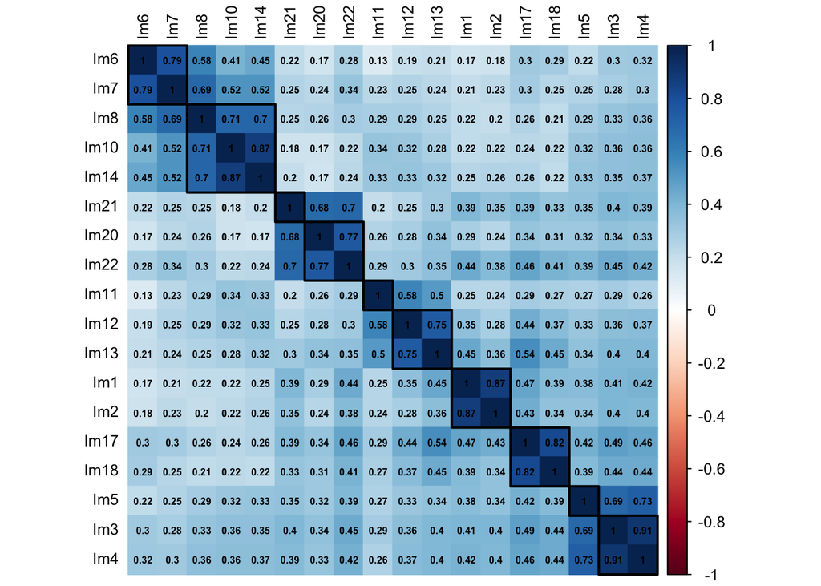

```r
#plot correlation matrix adjusting parameters to see previously identified groupings
corr_matrix <- cor(data_img_EFA2)
corrplot(as.matrix(corr_matrix),
         method = "color", #col = c("white","white","white","white","white", "lightgrey", "darkgrey", "black"),
         order = "hclust", addrect = 10, rect.col="black", # rect.col="red",
         addCoef.col = 'black', number.cex = .5,
         tl.col ="black",
         tl.cex = 0.80,
         )
```

Here we have excluded variables: *Im9, Im15, Im16, Im19* corresponding to *French Fashion, Professional Selection of Brands, Professional Appearance Towards Customers, Professional Organization* respectively

#### 2.2.3.2 Bartlett’s Test

```r
bart_spher(data_img_EFA2)
```

```
##  Bartlett's Test of Sphericity
##
## Call: bart_spher(x = data_img_EFA2)
##
##      X2 = 5526.103
##      df = 153
## p-value < 2.22e-16
```

The Bartlett Test tests the hypothesis that the sample originates from a population, where all variables are uncorrelated. This would not be good for factor analysis, we want this hypothesis to be rejected meaning p-value < 5%.

In our case we see that it is indeed rejected and that the data is not uncorrelated.

#### 2.2.3.3 KMO

```r
KMOTEST=KMOS(data_img_EFA2)
print(KMOTEST, sort=T)
```

```
##
## Kaiser-Meyer-Olkin Statistics
##
## Call: KMOS(x = data_img_EFA2)
##
## Measures of Sampling Adequacy (MSA):
##       Im2       Im1       Im6      Im10       Im7      Im20      Im18      Im14
## 0.7574828 0.7679602 0.7930679 0.8030643 0.8087243 0.8121780 0.8132056 0.8150036
##       Im4       Im3      Im17      Im12      Im13      Im22      Im11      Im21
## 0.8183748 0.8300720 0.8318320 0.8466594 0.8487869 0.8649099 0.8930642 0.9204703
##       Im8       Im5
## 0.9235082 0.9508366
##
## KMO-Criterion: 0.8355414
```

The KMO of 0.8355414 is above 0.6 which indicates the data is well suited for factor anlysis.

#### 2.2.3.4 Anti-image Correlation

```r
MSA_list <- data.table("Item"=names(KMOTEST$MSA), "MSA"=as.numeric(KMOTEST$MSA))

#Display table
MSA_list<- MSA_list |>
  setorder(cols = "MSA")

MSA_list |>
  stable() |>
  row_spec(which(MSA_list[,2]<0.5), bold = T, color = "white", background = "#78BE20")
```

| Item | MSA |
| --- | --- |
| Im2 | 0.76 |
| Im1 | 0.77 |
| Im6 | 0.79 |
| Im10 | 0.80 |
| Im7 | 0.81 |
| Im20 | 0.81 |
| Im18 | 0.81 |
| Im14 | 0.82 |
| Im4 | 0.82 |
| Im3 | 0.83 |
| Im17 | 0.83 |
| Im12 | 0.85 |
| Im13 | 0.85 |
| Im22 | 0.86 |
| Im11 | 0.89 |
| Im21 | 0.92 |
| Im8 | 0.92 |
| Im5 | 0.95 |

Here we have excluded variables: *Im9, Im15, Im16, Im19* corresponding to *French Fashion, Professional Selection of Brands, Professional Appearance Towards Customers, Professional Organization* respectively

Variables with MSA values above 0.5 are suited for factor analysis. Presence of items with low MSA’s (<0.5) could also indicate that an important topic hasn’t been well covered in the questionnaire.

All variables have MSA above 0.5

### 2.2.4 Select method: PAF

#### 2.2.4.1 Extract factors

```r
EFA_PAF0 <- psych::fa(data_img_EFA2, rotate="varimax", scores=TRUE)
# note: by default number of factors = 1 if it is not specified
```

##### 2.2.4.1.1 Scree plot

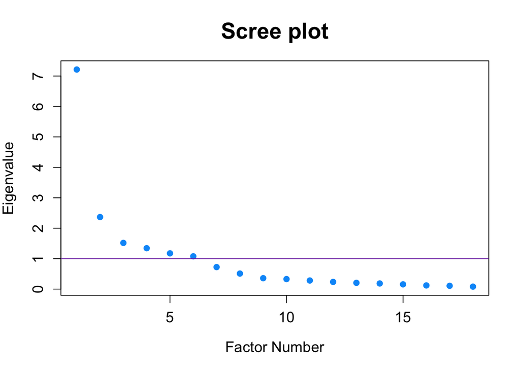

```r
#display Scree-plot
plot(EFA_PAF0$e.values,xlab="Factor Number",
     ylab="Eigenvalue",
     main="Scree plot",
     cex.lab=1.2,
     cex.axis=1.2,
     cex.main=1.8,
     col = "#0099F8",
     pch = 19)
abline(h=1, col = "#7F35B2")
```

Here we have excluded variables: *Im9, Im15, Im16, Im19* corresponding to *French Fashion, Professional Selection of Brands, Professional Appearance Towards Customers, Professional Organization* respectively

##### 2.2.4.1.2 Kaiser Criterion

```r
EFA_PAF0_kaiser_nb <- length(which(EFA_PAF0$e.values > 1))
EFA_PAF0_kaiser_nb
```

```
## [1] 6
```

The Kaiser criterion suggests we should retain factors with eigenvalues bigger than 1.

There are 6 factors satisfying this condition.

##### 2.2.4.1.3 Total Variance Explained

```r
#calculate total variance (does not change if number of factors change)
EFA_PAF0_EigenValue <- EFA_PAF0$e.values
EFA_PAF0_Variance <- EFA_PAF0_EigenValue / ncol(data_img_EFA2) * 100
EFA_PAF0_SumVariance <- cumsum(EFA_PAF0_EigenValue / ncol(data_img_EFA2))
EFA_PAF0_Total_Variance_Explained <- cbind("Factor number"=
                                            seq(1, length.out=length(EFA_PAF0_EigenValue[EFA_PAF0_EigenValue>0])),
                                          EigenValue = EFA_PAF0_EigenValue[EFA_PAF0_EigenValue>0],
                                          Variance = EFA_PAF0_Variance[EFA_PAF0_EigenValue>0],
                                          Total_Variance = EFA_PAF0_SumVariance[EFA_PAF0_EigenValue>0])
#display table
EFA_PAF0_Total_Variance_Explained |>
  stable()
```

| Factor number | EigenValue | Variance | Total_Variance |
| --- | --- | --- | --- |
| 1 | 7.21 | 40.07 | 0.40 |
| 2 | 2.37 | 13.15 | 0.53 |
| 3 | 1.52 | 8.43 | 0.62 |
| 4 | 1.34 | 7.47 | 0.69 |
| 5 | 1.18 | 6.53 | 0.76 |
| 6 | 1.08 | 5.99 | 0.82 |
| 7 | 0.72 | 4.02 | 0.86 |
| 8 | 0.51 | 2.84 | 0.89 |
| 9 | 0.36 | 1.99 | 0.90 |
| 10 | 0.33 | 1.83 | 0.92 |
| 11 | 0.28 | 1.57 | 0.94 |
| 12 | 0.24 | 1.31 | 0.95 |
| 13 | 0.21 | 1.15 | 0.96 |
| 14 | 0.19 | 1.03 | 0.97 |
| 15 | 0.16 | 0.87 | 0.98 |
| 16 | 0.12 | 0.68 | 0.99 |
| 17 | 0.11 | 0.61 | 1.00 |
| 18 | 0.08 | 0.45 | 1.00 |

Here we have excluded variables: *Im9, Im15, Im16, Im19* corresponding to *French Fashion, Professional Selection of Brands, Professional Appearance Towards Customers, Professional Organization* respectively

With 6 factors we would explain 81.6382115% of total variance.

With 7 factors we would explain 85.6588502% of total variance.

```r
# test eigenvalue calculation
factorloadings = EFA_PAF0$loadings[,1] # loadings 1st factor (default is nfactors = 1)
Eigenvalue = sum(factorloadings^2)
Eigenvalue
```

```
## [1] 6.596212
```

#### 2.2.4.2 Determine number of factors to retain

```r
# select nb of factors to test
nf = c(5,6,7,8)
```

#### 2.2.4.3 PAF orthogonal Varimax with n factors

```r
# perform multiple PAFs one for each factor number in selection
EFA_PAFn = list()

i=1
for (n in nf) {
  # EFA_PAFn[[i]] <- n
  EFA_PAFn[[i]] <- psych::fa(data_img_EFA2, rotate="varimax", scores=TRUE, nfactors = n)
  i=i+1
}
names(EFA_PAFn) <- nf
```

##### 2.2.4.3.1 Communalities

```r
#communalities for all selected number of factors

for (i in 1:length(nf)) {

  cat("###### Number of factors =", nf[[i]], "{.unnumbered}" ,"\n")

    EFA_PAFn_communalities <- data.table("Item"=names(EFA_PAFn[[i]]$communality),
                             "Communality"=as.numeric(EFA_PAFn[[i]]$communality))

    # Sort table
    EFA_PAFn_communalities <- EFA_PAFn_communalities |>
      setorder(cols = "Communality")

    # Display table
    kbl <- EFA_PAFn_communalities |>
              stable() |>
              row_spec(which(EFA_PAFn_communalities[,1]<.3), bold = T, color = "white", background = "#78BE20")

    print(kbl)
    cat("\n\n")

    # test communality calculation
    variableloading = EFA_PAFn[[i]]$loadings["Im6",] # loadings 1st variable
    communality = sum(variableloading^2)
    print(paste0("Communality for Im6 =", communality))
    cat("\n")

}
```

###### Number of factors = 5

| Item | Communality |
| --- | --- |
| Im11 | 0.39 |
| Im18 | 0.41 |
| Im6 | 0.48 |
| Im17 | 0.51 |
| Im5 | 0.57 |
| Im21 | 0.61 |
| Im7 | 0.65 |
| Im10 | 0.68 |
| Im14 | 0.70 |
| Im20 | 0.73 |
| Im13 | 0.73 |
| Im12 | 0.75 |
| Im8 | 0.75 |
| Im22 | 0.80 |
| Im2 | 0.81 |
| Im3 | 0.86 |
| Im1 | 0.91 |
| Im4 | 0.93 |

[1] “Communality for Im6 =0.47983655145029”

###### Number of factors = 6

| Item | Communality |
| --- | --- |
| Im11 | 0.43 |
| Im5 | 0.57 |
| Im21 | 0.61 |
| Im6 | 0.63 |
| Im18 | 0.66 |
| Im13 | 0.70 |
| Im10 | 0.72 |
| Im7 | 0.73 |
| Im8 | 0.73 |
| Im12 | 0.73 |
| Im14 | 0.74 |
| Im2 | 0.78 |
| Im22 | 0.79 |
| Im20 | 0.80 |
| Im17 | 0.80 |
| Im3 | 0.86 |
| Im4 | 0.94 |
| Im1 | 0.98 |

[1] “Communality for Im6 =0.625403738724852”

###### Number of factors = 7

| Item | Communality |
| --- | --- |
| Im11 | 0.41 |
| Im5 | 0.57 |
| Im21 | 0.61 |
| Im8 | 0.70 |
| Im13 | 0.70 |
| Im18 | 0.71 |
| Im6 | 0.75 |
| Im2 | 0.77 |
| Im22 | 0.79 |
| Im20 | 0.80 |
| Im14 | 0.83 |
| Im3 | 0.85 |
| Im12 | 0.86 |
| Im7 | 0.87 |
| Im10 | 0.92 |
| Im17 | 0.96 |
| Im4 | 0.97 |
| Im1 | 1.00 |

[1] “Communality for Im6 =0.745809206986154”

###### Number of factors = 8

| Item | Communality |
| --- | --- |
| Im5 | 0.57 |
| Im21 | 0.62 |
| Im12 | 0.67 |
| Im8 | 0.69 |
| Im6 | 0.73 |
| Im11 | 0.79 |
| Im22 | 0.79 |
| Im20 | 0.80 |
| Im2 | 0.82 |
| Im17 | 0.83 |
| Im18 | 0.83 |
| Im14 | 0.84 |
| Im3 | 0.85 |
| Im7 | 0.90 |
| Im10 | 0.91 |
| Im1 | 0.93 |
| Im13 | 0.94 |
| Im4 | 0.97 |

[1] “Communality for Im6 =0.729570059457077”

Typically we should think about excluding variables with communalities below 0.3.

Based on the above, no variable should be excluded.

##### 2.2.4.3.2 Factor loadings

```r
# loadings for all selected number of factors

for (i in 1:length(nf)) {

cat("###### Number of factors =", nf[[i]], "{.unnumbered}" ,"\n")

      # print(EFA_PAFn[[i]]$loadings, cutoff=0.3)
      # print(print_html(model_parameters(EFA_PAFn[[i]], loadings=T, threshold = 0.3, summary=T)))
     kbl <- model_parameters(EFA_PAFn[[i]], loadings=T, threshold = 0.3, summary=T) |>
        stable()
     print(kbl)

cat("\n\n")
}
```

###### Number of factors = 5

| Variable | MR2 | MR4 | MR1 | MR3 | MR5 | Complexity | Uniqueness |
| --- | --- | --- | --- | --- | --- | --- | --- |
| Im1 |  |  |  |  | 0.87 | 1.39 | 0.09 |
| Im2 |  |  |  |  | 0.84 | 1.31 | 0.19 |
| Im3 |  | 0.84 |  |  |  | 1.43 | 0.14 |
| Im4 |  | 0.89 |  |  |  | 1.35 | 0.07 |
| Im5 |  | 0.66 |  |  |  | 1.66 | 0.43 |
| Im6 | 0.65 |  |  |  |  | 1.25 | 0.52 |
| Im7 | 0.76 |  |  |  |  | 1.22 | 0.35 |
| Im8 | 0.84 |  |  |  |  | 1.15 | 0.25 |
| Im10 | 0.77 |  |  |  |  | 1.30 | 0.32 |
| Im11 |  |  | 0.56 |  |  | 1.47 | 0.61 |
| Im12 |  |  | 0.82 |  |  | 1.21 | 0.25 |
| Im13 |  |  | 0.78 |  |  | 1.40 | 0.27 |
| Im14 | 0.78 |  |  |  |  | 1.31 | 0.30 |
| Im17 |  | 0.34 | 0.43 | 0.31 | 0.30 | 3.91 | 0.49 |
| Im18 |  | 0.33 | 0.38 |  |  | 3.83 | 0.59 |
| Im20 |  |  |  | 0.81 |  | 1.20 | 0.27 |
| Im21 |  |  |  | 0.71 |  | 1.43 | 0.39 |
| Im22 |  |  |  | 0.81 |  | 1.45 | 0.20 |

###### Number of factors = 6

| Variable | MR2 | MR4 | MR3 | MR1 | MR5 | MR6 | Complexity | Uniqueness |
| --- | --- | --- | --- | --- | --- | --- | --- | --- |
| Im1 |  |  |  |  | 0.91 |  | 1.37 | 0.02 |
| Im2 |  |  |  |  | 0.81 |  | 1.38 | 0.22 |
| Im3 |  | 0.84 |  |  |  |  | 1.49 | 0.14 |
| Im4 |  | 0.89 |  |  |  |  | 1.40 | 0.06 |
| Im5 |  | 0.66 |  |  |  |  | 1.71 | 0.43 |
| Im6 | 0.70 |  |  |  |  | 0.33 | 1.55 | 0.37 |
| Im7 | 0.79 |  |  |  |  |  | 1.33 | 0.27 |
| Im8 | 0.82 |  |  |  |  |  | 1.21 | 0.27 |
| Im10 | 0.75 |  |  |  |  |  | 1.60 | 0.28 |
| Im11 |  |  |  | 0.59 |  |  | 1.46 | 0.57 |
| Im12 |  |  |  | 0.80 |  |  | 1.33 | 0.27 |
| Im13 |  |  |  | 0.72 |  |  | 1.75 | 0.30 |
| Im14 | 0.76 |  |  | 0.30 |  |  | 1.58 | 0.26 |
| Im17 |  |  |  | 0.31 |  | 0.73 | 2.14 | 0.20 |
| Im18 |  |  |  |  |  | 0.68 | 1.98 | 0.34 |
| Im20 |  |  | 0.86 |  |  |  | 1.18 | 0.20 |
| Im21 |  |  | 0.71 |  |  |  | 1.47 | 0.39 |
| Im22 |  |  | 0.80 |  |  |  | 1.53 | 0.21 |

###### Number of factors = 7

| Variable | MR4 | MR3 | MR2 | MR1 | MR7 | MR5 | MR6 | Complexity | Uniqueness |
| --- | --- | --- | --- | --- | --- | --- | --- | --- | --- |
| Im1 |  |  |  |  |  | 0.92 |  | 1.36 | 0.00 |
| Im2 |  |  |  |  |  | 0.80 |  | 1.40 | 0.23 |
| Im3 | 0.83 |  |  |  |  |  |  | 1.50 | 0.15 |
| Im4 | 0.91 |  |  |  |  |  |  | 1.36 | 0.03 |
| Im5 | 0.65 |  |  |  |  |  |  | 1.80 | 0.43 |
| Im6 |  |  |  |  | 0.80 |  |  | 1.32 | 0.25 |
| Im7 |  |  | 0.32 |  | 0.85 |  |  | 1.44 | 0.13 |
| Im8 |  |  | 0.60 |  | 0.52 |  |  | 2.39 | 0.30 |
| Im10 |  |  | 0.90 |  |  |  |  | 1.29 | 0.08 |
| Im11 |  |  |  | 0.56 |  |  |  | 1.67 | 0.59 |
| Im12 |  |  |  | 0.88 |  |  |  | 1.23 | 0.14 |
| Im13 |  |  |  | 0.72 |  |  |  | 1.73 | 0.30 |
| Im14 |  |  | 0.82 |  |  |  |  | 1.47 | 0.17 |
| Im17 |  |  |  |  |  |  | 0.86 | 1.66 | 0.04 |
| Im18 |  |  |  |  |  |  | 0.73 | 1.73 | 0.29 |
| Im20 |  | 0.86 |  |  |  |  |  | 1.17 | 0.20 |
| Im21 |  | 0.71 |  |  |  |  |  | 1.47 | 0.39 |
| Im22 |  | 0.79 |  |  |  |  |  | 1.54 | 0.21 |

###### Number of factors = 8

| Variable | MR1 | MR4 | MR2 | MR7 | MR5 | MR3 | MR6 | MR8 | Complexity | Uniqueness |
| --- | --- | --- | --- | --- | --- | --- | --- | --- | --- | --- |
| Im1 |  |  |  |  | 0.88 |  |  |  | 1.41 | 0.07 |
| Im2 |  |  |  |  | 0.84 |  |  |  | 1.34 | 0.18 |
| Im3 | 0.84 |  |  |  |  |  |  |  | 1.48 | 0.15 |
| Im4 | 0.92 |  |  |  |  |  |  |  | 1.35 | 0.03 |
| Im5 | 0.65 |  |  |  |  |  |  |  | 1.77 | 0.43 |
| Im6 |  |  |  | 0.79 |  |  |  |  | 1.35 | 0.27 |
| Im7 |  |  | 0.31 | 0.87 |  |  |  |  | 1.41 | 0.10 |
| Im8 |  |  | 0.60 | 0.52 |  |  |  |  | 2.37 | 0.31 |
| Im10 |  |  | 0.89 |  |  |  |  |  | 1.28 | 0.09 |
| Im11 |  |  |  |  |  | 0.36 |  | 0.75 | 1.82 | 0.21 |
| Im12 |  |  |  |  |  | 0.67 |  | 0.31 | 2.12 | 0.33 |
| Im13 |  |  |  |  |  | 0.87 |  |  | 1.50 | 0.06 |
| Im14 |  |  | 0.84 |  |  |  |  |  | 1.41 | 0.16 |
| Im17 |  |  |  |  |  |  | 0.76 |  | 1.95 | 0.17 |
| Im18 |  |  |  |  |  |  | 0.82 |  | 1.49 | 0.17 |
| Im20 |  | 0.86 |  |  |  |  |  |  | 1.16 | 0.20 |
| Im21 |  | 0.71 |  |  |  |  |  |  | 1.45 | 0.38 |
| Im22 |  | 0.80 |  |  |  |  |  |  | 1.55 | 0.21 |

Here we have excluded variables: *Im9, Im15, Im16, Im19* corresponding to *French Fashion, Professional Selection of Brands, Professional Appearance Towards Customers, Professional Organization* respectively

Thurstone simple structure criteria:

- Each row (variable) of the factor pattern matrix should have at least one zero
- Each column (factor) should have at least r zero elements, and the zeros for one factor should be unique from the zeros for the other factors
- For every pair of columns (factors), there should be at least r variables with a zero coefficient in one column and a non-zero coefficient in the other
- When r > 3 every pair of columns (factors), should contain a large proportion of variables with zeros in both columns
- For every pair of columns (factors), there should be only a small proportion of variables with non-zeros in both columns

#### 2.2.4.4 PAF oblique Promax with n factors

```r
# perform multiple PAFs one for each factor number in selection
EFA_PAFn_obl = list()

i=1
for (n in nf) {
  # EFA_PAFn_obl[[i]] <- n
  EFA_PAFn_obl[[i]] <- psych::fa(data_img_EFA2, rotate="promax", scores=TRUE, nfactors = n)
  i=i+1
}
names(EFA_PAFn_obl) <- nf

length(EFA_PAFn_obl)
```

```
## [1] 4
```

##### 2.2.4.4.1 Communalities

```r
#communalities for all selected number of factors

for (i in 1:length(nf)) {

  cat("###### Number of factors =", nf[[i]], "{.unnumbered}" ,"\n")

    EFA_PAFn_obl_communalities <- data.table("Item"=names(EFA_PAFn_obl[[i]]$communality),
                             "Communality"=as.numeric(EFA_PAFn_obl[[i]]$communality))

    # Sort table
    EFA_PAFn_obl_communalities <- EFA_PAFn_obl_communalities |>
      setorder(cols = "Communality")

    # Display table
    kbl <- EFA_PAFn_obl_communalities |>
              stable() |>
              row_spec(which(EFA_PAFn_obl_communalities[,1]<.3), bold = T, color = "white", background = "#78BE20")

    print(kbl)
    cat("\n\n")

    # test communality calculation
    variableloading = EFA_PAFn_obl[[i]]$loadings["Im6",] # loadings 1st variable
    communality = sum(variableloading^2)
    print(paste0("Communality for Im6 =", communality))
    cat("\n")

}
```

###### Number of factors = 5

| Item | Communality |
| --- | --- |
| Im11 | 0.39 |
| Im18 | 0.41 |
| Im6 | 0.48 |
| Im17 | 0.51 |
| Im5 | 0.57 |
| Im21 | 0.61 |
| Im7 | 0.65 |
| Im10 | 0.68 |
| Im14 | 0.70 |
| Im20 | 0.73 |
| Im13 | 0.73 |
| Im12 | 0.75 |
| Im8 | 0.75 |
| Im22 | 0.80 |
| Im2 | 0.81 |
| Im3 | 0.86 |
| Im1 | 0.91 |
| Im4 | 0.93 |

[1] “Communality for Im6 =0.487495170294562”

###### Number of factors = 6

| Item | Communality |
| --- | --- |
| Im11 | 0.43 |
| Im5 | 0.57 |
| Im21 | 0.61 |
| Im6 | 0.63 |
| Im18 | 0.66 |
| Im13 | 0.70 |
| Im10 | 0.72 |
| Im7 | 0.73 |
| Im8 | 0.73 |
| Im12 | 0.73 |
| Im14 | 0.74 |
| Im2 | 0.78 |
| Im22 | 0.79 |
| Im20 | 0.80 |
| Im17 | 0.80 |
| Im3 | 0.86 |
| Im4 | 0.94 |
| Im1 | 0.98 |

[1] “Communality for Im6 =0.721841095417957”

###### Number of factors = 7

| Item | Communality |
| --- | --- |
| Im11 | 0.41 |
| Im5 | 0.57 |
| Im21 | 0.61 |
| Im8 | 0.70 |
| Im13 | 0.70 |
| Im18 | 0.71 |
| Im6 | 0.75 |
| Im2 | 0.77 |
| Im22 | 0.79 |
| Im20 | 0.80 |
| Im14 | 0.83 |
| Im3 | 0.85 |
| Im12 | 0.86 |
| Im7 | 0.87 |
| Im10 | 0.92 |
| Im17 | 0.96 |
| Im4 | 0.97 |
| Im1 | 1.00 |

[1] “Communality for Im6 =0.817084805138536”

###### Number of factors = 8

| Item | Communality |
| --- | --- |
| Im5 | 0.57 |
| Im21 | 0.62 |
| Im12 | 0.67 |
| Im8 | 0.69 |
| Im6 | 0.73 |
| Im11 | 0.79 |
| Im22 | 0.79 |
| Im20 | 0.80 |
| Im2 | 0.82 |
| Im17 | 0.83 |
| Im18 | 0.83 |
| Im14 | 0.84 |
| Im3 | 0.85 |
| Im7 | 0.90 |
| Im10 | 0.91 |
| Im1 | 0.93 |
| Im13 | 0.94 |
| Im4 | 0.97 |

[1] “Communality for Im6 =0.796584681902646”

##### 2.2.4.4.2 Factor loadings

```r
# loadings for all selected number of factors

test = list()

for (i in 1:length(nf)) {

cat("###### Number of factors =", nf[[i]], "{.unnumbered}" ,"\n")

      # print(EFA_PAFn_obl[[i]]$loadings, cutoff=0.3)
      # print(print_html(model_parameters(EFA_PAFn_obl[[i]], loadings=T, threshold = 0.3, summary=T)))
     kbl <- model_parameters(EFA_PAFn_obl[[i]], loadings=T, threshold = 0.3, summary=T) |>
        stable()
     print(kbl)

cat("\n\n")
}
```

###### Number of factors = 5

| Variable | MR2 | MR4 | MR1 | MR3 | MR5 | Complexity | Uniqueness |
| --- | --- | --- | --- | --- | --- | --- | --- |
| Im1 |  |  |  |  | 1.01 | 1.01 | 0.09 |
| Im2 |  |  |  |  | 0.99 | 1.03 | 0.19 |
| Im3 |  | 1.00 |  |  |  | 1.01 | 0.14 |
| Im4 |  | 1.08 |  |  |  | 1.03 | 0.07 |
| Im5 |  | 0.75 |  |  |  | 1.00 | 0.43 |
| Im6 | 0.68 |  |  |  |  | 1.11 | 0.52 |
| Im7 | 0.80 |  |  |  |  | 1.12 | 0.35 |
| Im8 | 0.87 |  |  |  |  | 1.01 | 0.25 |
| Im10 | 0.78 |  |  |  |  | 1.17 | 0.32 |
| Im11 |  |  | 0.64 |  |  | 1.08 | 0.61 |
| Im12 |  |  | 0.97 |  |  | 1.03 | 0.25 |
| Im13 |  |  | 0.88 |  |  | 1.02 | 0.27 |
| Im14 | 0.79 |  |  |  |  | 1.16 | 0.30 |
| Im17 |  |  | 0.34 |  |  | 2.84 | 0.49 |
| Im18 |  |  |  |  |  | 2.89 | 0.59 |
| Im20 |  |  |  | 0.93 |  | 1.08 | 0.27 |
| Im21 |  |  |  | 0.77 |  | 1.03 | 0.39 |
| Im22 |  |  |  | 0.88 |  | 1.01 | 0.20 |

###### Number of factors = 6

| Variable | MR2 | MR4 | MR3 | MR1 | MR5 | MR6 | Complexity | Uniqueness |
| --- | --- | --- | --- | --- | --- | --- | --- | --- |
| Im1 |  |  |  |  | 1.00 |  | 1.01 | 0.02 |
| Im2 |  |  |  |  | 0.89 |  | 1.01 | 0.22 |
| Im3 |  | 0.92 |  |  |  |  | 1.02 | 0.14 |
| Im4 |  | 0.99 |  |  |  |  | 1.02 | 0.06 |
| Im5 |  | 0.70 |  |  |  |  | 1.02 | 0.43 |
| Im6 | 0.75 |  |  |  |  | 0.32 | 1.55 | 0.37 |
| Im7 | 0.85 |  |  |  |  |  | 1.25 | 0.27 |
| Im8 | 0.84 |  |  |  |  |  | 1.03 | 0.27 |
| Im10 | 0.74 |  |  |  |  |  | 1.44 | 0.28 |
| Im11 |  |  |  | 0.62 |  |  | 1.06 | 0.57 |
| Im12 |  |  |  | 0.86 |  |  | 1.07 | 0.27 |
| Im13 |  |  |  | 0.74 |  |  | 1.25 | 0.30 |
| Im14 | 0.75 |  |  |  |  |  | 1.39 | 0.26 |
| Im17 |  |  |  |  |  | 0.77 | 1.15 | 0.20 |
| Im18 |  |  |  |  |  | 0.72 | 1.13 | 0.34 |
| Im20 |  |  | 0.95 |  |  |  | 1.07 | 0.20 |
| Im21 |  |  | 0.74 |  |  |  | 1.04 | 0.39 |
| Im22 |  |  | 0.82 |  |  |  | 1.02 | 0.21 |

###### Number of factors = 7

| Variable | MR4 | MR2 | MR3 | MR1 | MR7 | MR5 | MR6 | Complexity | Uniqueness |
| --- | --- | --- | --- | --- | --- | --- | --- | --- | --- |
| Im1 |  |  |  |  |  | 1.01 |  | 1.01 | 0.00 |
| Im2 |  |  |  |  |  | 0.88 |  | 1.00 | 0.23 |
| Im3 | 0.92 |  |  |  |  |  |  | 1.00 | 0.15 |
| Im4 | 1.04 |  |  |  |  |  |  | 1.02 | 0.03 |
| Im5 | 0.68 |  |  |  |  |  |  | 1.04 | 0.43 |
| Im6 |  |  |  |  | 0.90 |  |  | 1.04 | 0.25 |
| Im7 |  |  |  |  | 0.92 |  |  | 1.02 | 0.13 |
| Im8 |  | 0.52 |  |  | 0.39 |  |  | 1.92 | 0.30 |
| Im10 |  | 1.03 |  |  |  |  |  | 1.03 | 0.08 |
| Im11 |  |  |  | 0.59 |  |  |  | 1.16 | 0.59 |
| Im12 |  |  |  | 1.00 |  |  |  | 1.04 | 0.14 |
| Im13 |  |  |  | 0.76 |  |  |  | 1.10 | 0.30 |
| Im14 |  | 0.91 |  |  |  |  |  | 1.01 | 0.17 |
| Im17 |  |  |  |  |  |  | 0.98 | 1.01 | 0.04 |
| Im18 |  |  |  |  |  |  | 0.83 | 1.01 | 0.29 |
| Im20 |  |  | 0.97 |  |  |  |  | 1.05 | 0.20 |
| Im21 |  |  | 0.75 |  |  |  |  | 1.04 | 0.39 |
| Im22 |  |  | 0.83 |  |  |  |  | 1.03 | 0.21 |

###### Number of factors = 8

| Variable | MR1 | MR2 | MR4 | MR7 | MR5 | MR6 | MR3 | MR8 | Complexity | Uniqueness |
| --- | --- | --- | --- | --- | --- | --- | --- | --- | --- | --- |
| Im1 |  |  |  |  | 0.95 |  |  |  | 1.02 | 0.07 |
| Im2 |  |  |  |  | 0.92 |  |  |  | 1.02 | 0.18 |
| Im3 | 0.93 |  |  |  |  |  |  |  | 1.00 | 0.15 |
| Im4 | 1.04 |  |  |  |  |  |  |  | 1.02 | 0.03 |
| Im5 | 0.69 |  |  |  |  |  |  |  | 1.04 | 0.43 |
| Im6 |  |  |  | 0.88 |  |  |  |  | 1.04 | 0.27 |
| Im7 |  |  |  | 0.95 |  |  |  |  | 1.02 | 0.10 |
| Im8 |  | 0.51 |  | 0.39 |  |  |  |  | 1.95 | 0.31 |
| Im10 |  | 1.02 |  |  |  |  |  |  | 1.03 | 0.09 |
| Im11 |  |  |  |  |  |  |  | 0.87 | 1.01 | 0.21 |
| Im12 |  |  |  |  |  |  | 0.66 |  | 1.19 | 0.33 |
| Im13 |  |  |  |  |  |  | 1.03 |  | 1.03 | 0.06 |
| Im14 |  | 0.93 |  |  |  |  |  |  | 1.01 | 0.16 |
| Im17 |  |  |  |  |  | 0.83 |  |  | 1.04 | 0.17 |
| Im18 |  |  |  |  |  | 0.96 |  |  | 1.01 | 0.17 |
| Im20 |  |  | 0.97 |  |  |  |  |  | 1.06 | 0.20 |
| Im21 |  |  | 0.75 |  |  |  |  |  | 1.03 | 0.38 |
| Im22 |  |  | 0.82 |  |  |  |  |  | 1.07 | 0.21 |

Here we have excluded variables: *Im9, Im15, Im16, Im19* corresponding to *French Fashion, Professional Selection of Brands, Professional Appearance Towards Customers, Professional Organization* respectively

## 2.3 Confirmatory factor analysis

We test whether the constructs found in the exploratory phase adequately describe what is going on.

### 2.3.1 6 factor model

```r
# # no excluded variables
# CFA_model_img_6f <- "
# DECO =~ Im3 + Im4 + Im5
# FRENCH =~ Im6 + Im7 + Im8 + Im10 + Im14
# ATMOS =~ Im20 + Im21 + Im22
# QUAL =~ Im11 + Im12 + Im13
# CHOICE =~ Im1 + Im2 + Im15 + Im16 + Im19
# BRAND =~ Im17 + Im18 + Im9
# "

# # excluded variables: Im9, Im15, Im16, Im19
# CFA_model_img_6f <- "
# QUAL =~ Im11 + Im12 + Im13
# FRENCH =~ Im6 + Im7 + Im8 + Im10 + Im14
# ATMOS =~ Im20 + Im21 + Im22
# DECO =~ Im3 + Im4 + Im5
# CHOICE =~ Im1 + Im2
# BRAND =~ Im17 + Im18
# "

# excluded variables: Im9, Im15, Im16, Im19, Im8
CFA_model_img_6f <- "
QUAL =~ Im11 + Im12 + Im13
FRENCH =~ Im6 + Im7 + Im10 + Im14
ATMOS =~ Im20 + Im21 + Im22
DECO =~ Im3 + Im4 + Im5
CHOICE =~ Im1 + Im2
BRAND =~ Im17 + Im18
"

# CFA_fit_img <- cfa(CFA_model_img_6f, data=data_img_EFA, missing="ML")
CFA_fit_img_6f <- cfa(CFA_model_img_6f, data=survey, missing="ML")

summary(CFA_fit_img_6f, fit.measures=TRUE, standardized=TRUE)
```

```
## lavaan 0.6.15 ended normally after 101 iterations
##
##   Estimator                                         ML
##   Optimization method                           NLMINB
##   Number of model parameters                        66
##
##   Number of observations                           553
##   Number of missing patterns                        69
##
## Model Test User Model:
##
##   Test statistic                               596.827
##   Degrees of freedom                               104
##   P-value (Chi-square)                           0.000
##
## Model Test Baseline Model:
##
##   Test statistic                              6781.361
##   Degrees of freedom                               136
##   P-value                                        0.000
##
## User Model versus Baseline Model:
##
##   Comparative Fit Index (CFI)                    0.926
##   Tucker-Lewis Index (TLI)                       0.903
##
##   Robust Comparative Fit Index (CFI)             0.926
##   Robust Tucker-Lewis Index (TLI)                0.903
##
## Loglikelihood and Information Criteria:
##
##   Loglikelihood user model (H0)             -11806.949
##   Loglikelihood unrestricted model (H1)     -11508.536
##
##   Akaike (AIC)                               23745.899
##   Bayesian (BIC)                             24030.712
##   Sample-size adjusted Bayesian (SABIC)      23821.199
##
## Root Mean Square Error of Approximation:
##
```

[output cut: 107 more lines]

```
##    .Im21              0.720    0.057   12.652    0.000    0.720    0.383
##    .Im22              0.554    0.063    8.777    0.000    0.554    0.237
##    .Im3               0.215    0.025    8.754    0.000    0.215    0.123
##    .Im4               0.108    0.024    4.417    0.000    0.108    0.059
##    .Im5               0.744    0.049   15.187    0.000    0.744    0.420
##    .Im1               0.049    0.057    0.860    0.390    0.049    0.027
##    .Im2               0.334    0.048    6.992    0.000    0.334    0.202
##    .Im17              0.116    0.046    2.520    0.012    0.116    0.075
##    .Im18              0.500    0.056    8.978    0.000    0.500    0.256
##     QUAL              0.494    0.067    7.352    0.000    1.000    1.000
##     FRENCH            0.355    0.059    5.984    0.000    1.000    1.000
##     ATMOS             1.608    0.138   11.675    0.000    1.000    1.000
##     DECO              1.527    0.107   14.300    0.000    1.000    1.000
##     CHOICE            1.728    0.122   14.217    0.000    1.000    1.000
##     BRAND             1.432    0.104   13.730    0.000    1.000    1.000
```

#### 2.3.1.1 Discussion of global fit measures

Chi square: p-value > 0.05

RMSEA RMSEA <= 0.05 Good fit 0.05 < RMSEA <= 0.08 Acceptable fit 0.08 < RMSEA <= 0.10 Bad fit RMSEA > 0.1 Unacceptable fit

CFI CFI < 0.90 definitely reject model 0.90 < CFI < 0.95 high underrejection rates for misspecified models CFI > 0.95 accept model

#### 2.3.1.2 local fit measures

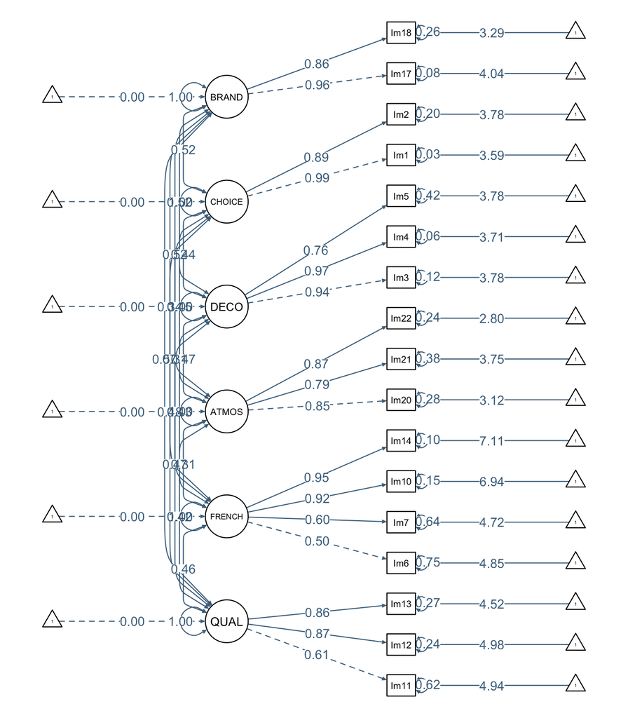

```r
# semPaths(CFA_fit_img_6f, what = "path", whatLabels = "std", style = "mx",
#          rotation = 2, layout = "tree3", mar = c(1, 2, 1, 2),
#          nCharNodes = 7,shapeMan = "rectangle", sizeMan = 8, sizeMan2 = 5,
#          curvePivot=TRUE, edge.label.cex = 1.2, edge.color = "skyblue4")


semPaths(CFA_fit_img_6f, what = "path", whatLabels = "std", style = "mx",
         rotation = 2, layout = "tree3", mar = c(1, 2, 1, 2),
         nCharNodes = 7,shapeMan = "rectangle",
         sizeMan = 4, sizeMan2 = 3, sizeInt = 2, sizeLat = 6, asize = 1.5,
         curvePivot=TRUE, edge.label.cex = .8, edge.color = "skyblue4"
         )
```

```r
lambda = inspect(CFA_fit_img_6f, what="std")$lambda
theta = inspect(CFA_fit_img_6f, what="std")$theta

# create lambda matrix with ones instead of std.all
ones <- lambda
ones[ones>0] <- 1

# a matrix with dimensions of lambda matrix but with lambdas replaced by thetas
theta_lb <- theta %*% ones
```

##### 2.3.1.2.1 Indicator reliability criterion

```r
# calculate indicator reliabilities (should be larger than 0.4)
indicrel <- lambda^2/(lambda^2 + theta_lb)
# indicrel

# replace all values satisfying condition with NaN for visibility
indicrel_fail <- indicrel
indicrel_fail[indicrel_fail>.4] <- NaN
indicrel_fail
```

```
##       QUAL FRENCH ATMOS DECO CHOICE BRAND
## Im11 0.377    NaN   NaN  NaN    NaN   NaN
## Im12   NaN    NaN   NaN  NaN    NaN   NaN
## Im13   NaN    NaN   NaN  NaN    NaN   NaN
## Im6    NaN  0.246   NaN  NaN    NaN   NaN
## Im7    NaN  0.359   NaN  NaN    NaN   NaN
## Im10   NaN    NaN   NaN  NaN    NaN   NaN
## Im14   NaN    NaN   NaN  NaN    NaN   NaN
## Im20   NaN    NaN   NaN  NaN    NaN   NaN
## Im21   NaN    NaN   NaN  NaN    NaN   NaN
## Im22   NaN    NaN   NaN  NaN    NaN   NaN
## Im3    NaN    NaN   NaN  NaN    NaN   NaN
## Im4    NaN    NaN   NaN  NaN    NaN   NaN
## Im5    NaN    NaN   NaN  NaN    NaN   NaN
## Im1    NaN    NaN   NaN  NaN    NaN   NaN
## Im2    NaN    NaN   NaN  NaN    NaN   NaN
## Im17   NaN    NaN   NaN  NaN    NaN   NaN
## Im18   NaN    NaN   NaN  NaN    NaN   NaN
```

##### 2.3.1.2.2 Construct reliability criterion

```r
# calculate construct reliability (should be above .6)
constrrel <- (t(lambda) %*% ones)^2 / ((t(lambda) %*% ones)^2 + t(theta_lb) %*% ones )
# constrrel

# replace all values satisfying condition with NaN for visibility
constrrel_fail <- constrrel
constrrel_fail[constrrel_fail>.6] <- NaN
constrrel_fail
```

```
##        QUAL FRENCH ATMOS DECO CHOICE BRAND
## QUAL    NaN    NaN   NaN  NaN    NaN   NaN
## FRENCH  NaN    NaN   NaN  NaN    NaN   NaN
## ATMOS   NaN    NaN   NaN  NaN    NaN   NaN
## DECO    NaN    NaN   NaN  NaN    NaN   NaN
## CHOICE  NaN    NaN   NaN  NaN    NaN   NaN
## BRAND   NaN    NaN   NaN  NaN    NaN   NaN
```

##### 2.3.1.2.3 Average Variance Extracted criterion

```r
# calculate Average Variance Extracted (should be above .5)
AVE <- (t(lambda) %*% lambda) / (t(lambda) %*% lambda + t(theta_lb) %*% ones )
# avgvar

# replace all values satisfying condition with NaN for visibility
AVE_fail <- AVE
AVE_fail[AVE_fail>.5] <- NaN
AVE_fail
```

```
##        QUAL FRENCH ATMOS DECO CHOICE BRAND
## QUAL    NaN    NaN   NaN  NaN    NaN   NaN
## FRENCH  NaN    NaN   NaN  NaN    NaN   NaN
## ATMOS   NaN    NaN   NaN  NaN    NaN   NaN
## DECO    NaN    NaN   NaN  NaN    NaN   NaN
## CHOICE  NaN    NaN   NaN  NaN    NaN   NaN
## BRAND   NaN    NaN   NaN  NaN    NaN   NaN
```

##### 2.3.1.2.4 Fornell-Larcker Criteria

```r
# correlations between constructs (factors...) should be lower than .7
psi = inspect(CFA_fit_img_6f, what="std")$psi
psi_fail <- psi
psi_fail[psi_fail<.7] <- NaN
psi_fail
```

```
##        QUAL FRENCH ATMOS DECO CHOICE BRAND
## QUAL      1
## FRENCH  NaN      1
## ATMOS   NaN    NaN     1
## DECO    NaN    NaN   NaN    1
## CHOICE  NaN    NaN   NaN  NaN      1
## BRAND   NaN    NaN   NaN  NaN    NaN     1
```

```r
# AVE should be higher than squared correlations between constructs

# replace diagonal of psi matrix with AVE values
psi2 <- psi - psi * diag(1,nrow(psi),ncol(psi)) + diag(AVE) * diag(1,nrow(AVE),ncol(AVE))

# create matrix with columns filled with AVE
AVE_full <- AVE
AVE_full[is.na(AVE_full)] <- 0 #replace NAs with 0s
AVE_full <- AVE_full^0 %*% AVE_full # multiply a matrix full of ones with AVE_full to get columns filled with AVE

# substract matrices any psi bigger than AVE will be negative
AVEpsi_fail <- AVE_full - psi2
# AVE_full - psi2
AVEpsi_fail[AVEpsi_fail >= 0] <- NaN

AVE_full
```

```
##             QUAL   FRENCH     ATMOS      DECO   CHOICE     BRAND
## QUAL   0.6229823 0.587422 0.6993366 0.7989827 0.885422 0.8346058
## FRENCH 0.6229823 0.587422 0.6993366 0.7989827 0.885422 0.8346058
## ATMOS  0.6229823 0.587422 0.6993366 0.7989827 0.885422 0.8346058
## DECO   0.6229823 0.587422 0.6993366 0.7989827 0.885422 0.8346058
## CHOICE 0.6229823 0.587422 0.6993366 0.7989827 0.885422 0.8346058
## BRAND  0.6229823 0.587422 0.6993366 0.7989827 0.885422 0.8346058
```

```r
psi
```

```
##         QUAL FRENCH ATMOS  DECO CHOICE BRAND
## QUAL   1.000
## FRENCH 0.456  1.000
## ATMOS  0.419  0.310 1.000
## DECO   0.472  0.427 0.466 1.000
## CHOICE 0.477  0.311 0.447 0.439  1.000
## BRAND  0.569  0.341 0.519 0.521  0.519 1.000
```

```r
AVEpsi_fail
```

```
##          QUAL FRENCH  ATMOS   DECO CHOICE  BRAND
## QUAL        .
## FRENCH    NaN      .
## ATMOS     NaN    NaN      .
## DECO      NaN    NaN    NaN      .
## CHOICE    NaN    NaN    NaN    NaN      .
## BRAND     NaN    NaN    NaN    NaN    NaN      .
```

#### 2.3.1.3 Modification indices

```r
arrange(modificationindices(CFA_fit_img_6f),-mi)
```

```
##        lhs op  rhs      mi    epc sepc.lv sepc.all sepc.nox
## 1      Im6 ~~  Im7 266.988  0.754   0.754    0.741    0.741
## 2     Im10 ~~ Im14 160.755  0.559   0.559    5.912    5.912
## 3    BRAND =~ Im13  23.328  0.222   0.265    0.220    0.220
## 4      Im7 ~~ Im14  22.052 -0.117  -0.117   -0.437   -0.437
## 5      Im6 ~~ Im10  21.899 -0.106  -0.106   -0.294   -0.294
## 6     Im11 ~~ Im13  21.401 -0.192  -0.192   -0.341   -0.341
## 7    BRAND =~ Im12  17.067 -0.181  -0.217   -0.191   -0.191
## 8    ATMOS =~  Im7  17.051  0.160   0.202    0.166    0.166
## 9    BRAND =~  Im6  15.583  0.166   0.199    0.166    0.166
## 10  CHOICE =~ Im20  15.563 -0.153  -0.201   -0.134   -0.134
## 11  CHOICE =~ Im13  14.166  0.132   0.174    0.144    0.144
## 12    Im11 ~~ Im12  13.823  0.148   0.148    0.294    0.294
## 13    Im21 ~~ Im22  13.693 -0.276  -0.276   -0.438   -0.438
## 14     Im3 ~~  Im4  12.840  0.287   0.287    1.881    1.881
```

[output cut: 205 more lines]

Based on the modification indices we create a new model

```r
# # no excluded variables:
# CFA_model_img_7f <- "
# DECO =~ Im3 + Im4 + Im5
# FOOD =~ Im8 + Im10 + Im14
# ATMOS =~ Im20 + Im21 + Im22
# PRODQUAL =~ Im11 + Im12 + Im13
# CHOICE =~ Im1 + Im2 + Im15
# SERVQUAL =~ Im16 + Im19
# BRAND =~ Im17 + Im18
# FRENCH =~ Im6 + Im7 + Im9
# "

# # excluded variables: Im9, Im15, Im16, Im19
# CFA_model_img_7f <- "
# QUAL =~ Im11 + Im12 + Im13
# FOOD =~ Im8 + Im10 + Im14
# ATMOS =~ Im20 + Im21 + Im22
# DECO =~ Im3 + Im4 + Im5
# CHOICE =~ Im1 + Im2
# BRAND =~ Im17 + Im18
# FRENCH =~ Im6 + Im7
# "

# # excluded variables: Im9, Im15, Im16, Im19, Im8
# CFA_model_img_7f <- "
# QUAL =~ Im11 + Im12 + Im13
# FOOD =~ Im10 + Im14
# ATMOS =~ Im20 + Im21 + Im22
# DECO =~ Im3 + Im4 + Im5
# CHOICE =~ Im1 + Im2
# BRAND =~ Im17 + Im18
# FRENCH =~ Im6 + Im7
# "

# 8 factor model: excluded variables: Im9, Im15, Im11
CFA_model_img_7f <- "
QUAL =~ Im12 + Im13
FOOD =~ Im8 + Im10 + Im14
ATMOS =~ Im20 + Im21 + Im22
DECO =~ Im3 + Im4 + Im5
CHOICE =~ Im1 + Im2
BRAND =~ Im17 + Im18
FRENCH =~ Im6 + Im7
PROF =~ Im16 + Im19
"


CFA_fit_img_7f <- cfa(CFA_model_img_7f, data=survey, missing="ML")
summary(CFA_fit_img_7f, fit.measures=TRUE, standardized=TRUE)
```

```
## lavaan 0.6.15 ended normally after 104 iterations
##
##   Estimator                                         ML
##   Optimization method                           NLMINB
##   Number of model parameters                        85
##
##   Number of observations                           553
##   Number of missing patterns                        77
##
## Model Test User Model:
##
##   Test statistic                               371.225
##   Degrees of freedom                               124
##   P-value (Chi-square)                           0.000
##
## Model Test Baseline Model:
##
##   Test statistic                              7763.911
##   Degrees of freedom                               171
##   P-value                                        0.000
##
## User Model versus Baseline Model:
##
##   Comparative Fit Index (CFI)                    0.967
##   Tucker-Lewis Index (TLI)                       0.955
##
##   Robust Comparative Fit Index (CFI)             0.967
##   Robust Tucker-Lewis Index (TLI)                0.955
##
## Loglikelihood and Information Criteria:
##
##   Loglikelihood user model (H0)             -12853.361
##   Loglikelihood unrestricted model (H1)     -12667.749
##
##   Akaike (AIC)                               25876.723
##   Bayesian (BIC)                             26243.528
##   Sample-size adjusted Bayesian (SABIC)      25973.700
##
## Root Mean Square Error of Approximation:
##
```

[output cut: 134 more lines]

```
##    .Im2               0.326    0.044    7.428    0.000    0.326    0.197
##    .Im17              0.088    0.045    1.956    0.050    0.088    0.057
##    .Im18              0.529    0.054    9.729    0.000    0.529    0.270
##    .Im6               0.497    0.053    9.354    0.000    0.497    0.346
##    .Im7               0.115    0.062    1.849    0.064    0.115    0.079
##    .Im16              0.595    0.052   11.448    0.000    0.595    0.411
##    .Im19              0.342    0.045    7.561    0.000    0.342    0.270
##     QUAL              0.856    0.084   10.184    0.000    1.000    1.000
##     FOOD              0.603    0.062    9.785    0.000    1.000    1.000
##     ATMOS             1.597    0.138   11.610    0.000    1.000    1.000
##     DECO              1.527    0.107   14.326    0.000    1.000    1.000
##     CHOICE            1.715    0.119   14.460    0.000    1.000    1.000
##     BRAND             1.459    0.104   14.070    0.000    1.000    1.000
##     FRENCH            0.942    0.092   10.187    0.000    1.000    1.000
##     PROF              0.853    0.088    9.667    0.000    1.000    1.000
```

#### 2.3.2.1 Discussion of global fit measures

Chi square: p-value > 0.05

RMSEA RMSEA <= 0.05 Good fit 0.05 < RMSEA <= 0.08 Acceptable fit 0.08 < RMSEA <= 0.10 Bad fit RMSEA > 0.1 Unacceptable fit

CFI CFI < 0.90 definitely reject model 0.90 < CFI < 0.95 high underrejection rates for misspecified models CFI > 0.95 accept model

#### 2.3.2.2 local fit measures

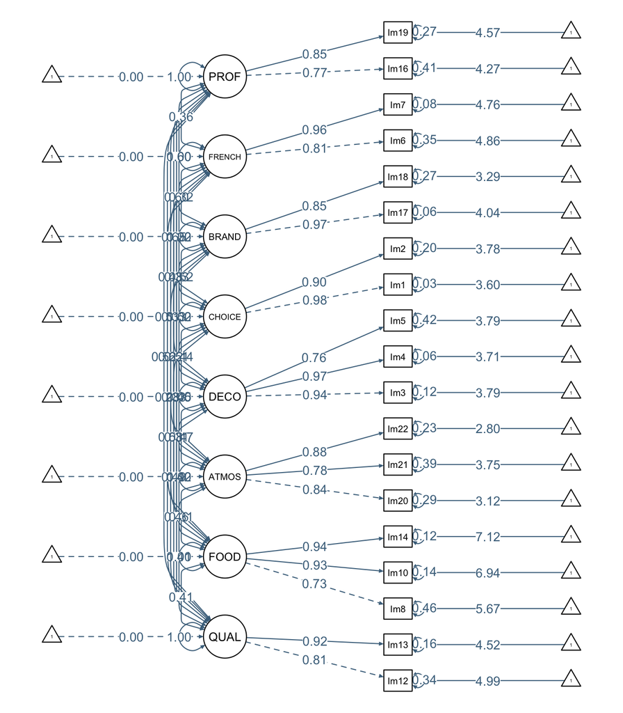

```r
# semPaths(CFA_fit_img_7f, what = "path", whatLabels = "std", style = "mx",
#          rotation = 2, layout = "tree3", mar = c(1, 2, 1, 2),
#          nCharNodes = 7,shapeMan = "rectangle", sizeMan = 8, sizeMan2 = 5,
#          curvePivot=TRUE, edge.label.cex = 1.2, edge.color = "skyblue4")


semPaths(CFA_fit_img_7f, what = "path", whatLabels = "std", style = "mx",
         rotation = 2, layout = "tree3", mar = c(1, 2, 1, 2),
         nCharNodes = 7,shapeMan = "rectangle",
         sizeMan = 4, sizeMan2 = 3, sizeInt = 2, sizeLat = 6, asize = 1.5,
         curvePivot=TRUE, edge.label.cex = .8, edge.color = "skyblue4"
         )
```

```r
lambda = inspect(CFA_fit_img_7f, what="std")$lambda
theta = inspect(CFA_fit_img_7f, what="std")$theta

# create lambda matrix with ones instead of std.all
ones <- lambda
ones[ones>0] <- 1

# a matrix with dimensions of lambda matrix but with lambdas replaced by thetas
theta_lb <- theta %*% ones
```

##### 2.3.2.2.1 Indicator reliability criterion

```r
# calculate indicator reliabilities (should be larger than 0.4)
indicrel <- lambda^2/(lambda^2 + theta_lb)
# indicrel

# replace all values satisfying condition with NaN for visibility
indicrel_fail <- indicrel
indicrel_fail[indicrel_fail>.4] <- NaN
indicrel_fail
```

```
##      QUAL FOOD ATMOS DECO CHOICE BRAND FRENCH PROF
## Im12  NaN  NaN   NaN  NaN    NaN   NaN    NaN  NaN
## Im13  NaN  NaN   NaN  NaN    NaN   NaN    NaN  NaN
## Im8   NaN  NaN   NaN  NaN    NaN   NaN    NaN  NaN
## Im10  NaN  NaN   NaN  NaN    NaN   NaN    NaN  NaN
## Im14  NaN  NaN   NaN  NaN    NaN   NaN    NaN  NaN
## Im20  NaN  NaN   NaN  NaN    NaN   NaN    NaN  NaN
## Im21  NaN  NaN   NaN  NaN    NaN   NaN    NaN  NaN
## Im22  NaN  NaN   NaN  NaN    NaN   NaN    NaN  NaN
## Im3   NaN  NaN   NaN  NaN    NaN   NaN    NaN  NaN
## Im4   NaN  NaN   NaN  NaN    NaN   NaN    NaN  NaN
## Im5   NaN  NaN   NaN  NaN    NaN   NaN    NaN  NaN
## Im1   NaN  NaN   NaN  NaN    NaN   NaN    NaN  NaN
## Im2   NaN  NaN   NaN  NaN    NaN   NaN    NaN  NaN
## Im17  NaN  NaN   NaN  NaN    NaN   NaN    NaN  NaN
## Im18  NaN  NaN   NaN  NaN    NaN   NaN    NaN  NaN
## Im6   NaN  NaN   NaN  NaN    NaN   NaN    NaN  NaN
## Im7   NaN  NaN   NaN  NaN    NaN   NaN    NaN  NaN
## Im16  NaN  NaN   NaN  NaN    NaN   NaN    NaN  NaN
## Im19  NaN  NaN   NaN  NaN    NaN   NaN    NaN  NaN
```

##### 2.3.2.2.2 Construct reliability criterion

```r
# calculate construct reliability (should be above .6)
constrrel <- (t(lambda) %*% ones)^2 / ((t(lambda) %*% ones)^2 + t(theta_lb) %*% ones )
# constrrel

# replace all values satisfying condition with NaN for visibility
constrrel_fail <- constrrel
constrrel_fail[constrrel_fail>.6] <- NaN
constrrel_fail
```

```
##        QUAL FOOD ATMOS DECO CHOICE BRAND FRENCH PROF
## QUAL    NaN  NaN   NaN  NaN    NaN   NaN    NaN  NaN
## FOOD    NaN  NaN   NaN  NaN    NaN   NaN    NaN  NaN
## ATMOS   NaN  NaN   NaN  NaN    NaN   NaN    NaN  NaN
## DECO    NaN  NaN   NaN  NaN    NaN   NaN    NaN  NaN
## CHOICE  NaN  NaN   NaN  NaN    NaN   NaN    NaN  NaN
## BRAND   NaN  NaN   NaN  NaN    NaN   NaN    NaN  NaN
## FRENCH  NaN  NaN   NaN  NaN    NaN   NaN    NaN  NaN
## PROF    NaN  NaN   NaN  NaN    NaN   NaN    NaN  NaN
```

##### 2.3.2.2.3 Average Variance Extracted criterion

```r
# calculate Average Variance Extracted (should be above .5)
AVE <- (t(lambda) %*% lambda) / (t(lambda) %*% lambda + t(theta_lb) %*% ones )
# avgvar

# replace all values satisfying condition with NaN for visibility
AVE_fail <- AVE
AVE_fail[AVE_fail>.5] <- NaN
AVE_fail
```

```
##        QUAL FOOD ATMOS DECO CHOICE BRAND FRENCH PROF
## QUAL    NaN  NaN   NaN  NaN    NaN   NaN    NaN  NaN
## FOOD    NaN  NaN   NaN  NaN    NaN   NaN    NaN  NaN
## ATMOS   NaN  NaN   NaN  NaN    NaN   NaN    NaN  NaN
## DECO    NaN  NaN   NaN  NaN    NaN   NaN    NaN  NaN
## CHOICE  NaN  NaN   NaN  NaN    NaN   NaN    NaN  NaN
## BRAND   NaN  NaN   NaN  NaN    NaN   NaN    NaN  NaN
## FRENCH  NaN  NaN   NaN  NaN    NaN   NaN    NaN  NaN
## PROF    NaN  NaN   NaN  NaN    NaN   NaN    NaN  NaN
```

##### 2.3.2.2.4 Fornell-Larcker Criteria

```r
# correlations between constructs (factors...) should be lower than .7
psi = inspect(CFA_fit_img_7f, what="std")$psi
psi_fail <- psi
psi_fail[psi_fail<.7] <- NaN
psi_fail
```

```
##        QUAL FOOD ATMOS DECO CHOICE BRAND FRENCH PROF
## QUAL      1
## FOOD    NaN    1
## ATMOS   NaN  NaN     1
## DECO    NaN  NaN   NaN    1
## CHOICE  NaN  NaN   NaN  NaN      1
## BRAND   NaN  NaN   NaN  NaN    NaN     1
## FRENCH  NaN  NaN   NaN  NaN    NaN   NaN      1
## PROF    NaN  NaN   NaN  NaN    NaN   NaN    NaN    1
```

```r
# AVE should be higher than squared correlations between constructs

# replace diagonal of psi matrix with AVE values
psi2 <- psi - psi * diag(1,nrow(psi),ncol(psi)) + diag(AVE) * diag(1,nrow(AVE),ncol(AVE))

# create matrix with columns filled with AVE
AVE_full <- AVE
AVE_full[is.na(AVE_full)] <- 0 #replace NAs with 0s
AVE_full <- AVE_full^0 %*% AVE_full # multiply a matrix full of ones with AVE_full to get columns filled with AVE

# substract matrices, replace all values satisfying positive condition (AVE > psi) with NaN
AVEpsi_fail <- AVE_full - psi2
# AVE_full - psi2
AVEpsi_fail[AVEpsi_fail >= 0] <- NaN

AVE_full
```

```
##             QUAL      FOOD     ATMOS      DECO    CHOICE     BRAND    FRENCH
## QUAL   0.7537361 0.7597697 0.6989747 0.7983475 0.8847657 0.8364178 0.7878839
## FOOD   0.7537361 0.7597697 0.6989747 0.7983475 0.8847657 0.8364178 0.7878839
## ATMOS  0.7537361 0.7597697 0.6989747 0.7983475 0.8847657 0.8364178 0.7878839
## DECO   0.7537361 0.7597697 0.6989747 0.7983475 0.8847657 0.8364178 0.7878839
## CHOICE 0.7537361 0.7597697 0.6989747 0.7983475 0.8847657 0.8364178 0.7878839
## BRAND  0.7537361 0.7597697 0.6989747 0.7983475 0.8847657 0.8364178 0.7878839
## FRENCH 0.7537361 0.7597697 0.6989747 0.7983475 0.8847657 0.8364178 0.7878839
## PROF   0.7537361 0.7597697 0.6989747 0.7983475 0.8847657 0.8364178 0.7878839
##             PROF
## QUAL   0.6595565
## FOOD   0.6595565
## ATMOS  0.6595565
## DECO   0.6595565
## CHOICE 0.6595565
## BRAND  0.6595565
## FRENCH 0.6595565
## PROF   0.6595565
```

```r
psi
```

```
##         QUAL  FOOD ATMOS  DECO CHOICE BRAND FRENCH  PROF
## QUAL   1.000
## FOOD   0.412 1.000
## ATMOS  0.407 0.307 1.000
## DECO   0.463 0.422 0.467 1.000
## CHOICE 0.489 0.306 0.448 0.439  1.000
## BRAND  0.579 0.328 0.515 0.516  0.517 1.000
## FRENCH 0.283 0.618 0.332 0.331  0.223 0.319  1.000
## PROF   0.517 0.507 0.479 0.653  0.595 0.601  0.364 1.000
```

```r
AVEpsi_fail
```

```
##          QUAL   FOOD  ATMOS   DECO CHOICE  BRAND FRENCH   PROF
## QUAL        .
## FOOD      NaN      .
## ATMOS     NaN    NaN      .
## DECO      NaN    NaN    NaN      .
## CHOICE    NaN    NaN    NaN    NaN      .
## BRAND     NaN    NaN    NaN    NaN    NaN      .
## FRENCH    NaN    NaN    NaN    NaN    NaN    NaN      .
## PROF      NaN    NaN    NaN    NaN    NaN    NaN    NaN      .
```

#### 2.3.2.3 Modification indices

```r
arrange(modificationindices(CFA_fit_img_7f),-mi)
```

```
##        lhs op  rhs      mi    epc sepc.lv sepc.all sepc.nox
## 1   FRENCH =~  Im8 132.435  0.530   0.514    0.486    0.486
## 2     Im10 ~~ Im14  92.349  0.294   0.294    3.001    3.001
## 3      Im8 ~~  Im7  53.488  0.170   0.170    0.697    0.697
## 4   FRENCH =~ Im10  16.186 -0.122  -0.118   -0.134   -0.134
## 5      Im8 ~~ Im14  16.161 -0.080  -0.080   -0.374   -0.374
## 6     Im21 ~~ Im22  15.737 -0.291  -0.291   -0.466   -0.466
## 7   CHOICE =~ Im20  14.649 -0.149  -0.195   -0.131   -0.131
## 8     FOOD =~ Im12  11.903  0.199   0.154    0.136    0.136
## 9     FOOD =~ Im13  11.903 -0.238  -0.185   -0.153   -0.153
## 10    Im20 ~~ Im21  11.849  0.232   0.232    0.341    0.341
## 11    Im14 ~~  Im7  11.333 -0.046  -0.046   -0.454   -0.454
## 12  FRENCH =~ Im14   9.971 -0.094  -0.091   -0.106   -0.106
## 13     Im4 ~~ Im17   9.239 -0.046  -0.046   -0.467   -0.467
## 14   ATMOS =~  Im8   8.863  0.086   0.108    0.102    0.102
```

[output cut: 285 more lines]

### 2.3.3 Factor scores for path analysis

```r
## don't actually think we need this as we can use the full data for confirmatory and path analysis
# data_img_EFA2
# data.frame(EFA_PAFn[[3]]$scores)
#
# numcol_data_img_EFA = dim(data_img_EFA2)[2]
# numcol_scores = dim(EFA_PAFn[[3]]$scores)[2]
# numcol_data_img_EFA
# numcol_scores
#
# CFA_data = cbind(data_img_EFA2, EFA_PAFn[[3]]$scores, survey_excl_img2["SAT_1"])
# CFA_data
# # colnames(CFA_data)[23:29] = c("Gourmet food", "Brand image", "Choice range", "Relaxed atmosphere", "Decoration", "Product quality", "Frenchness")
#
# # colnames(CFA_data)[numcol_data_img_EFA:(numcol_data_img_EFA + numcol_scores)] = c("FOOD", "BRAND", "CHOICE", "ATMOS", "DECO")
# colnames(CFA_data)[numcol_data_img_EFA:(numcol_data_img_EFA + numcol_scores)] = c("FOOD", "BRAND", "CHOICE", "ATMOS", "DECO", "QUAL", "FRENCH")
#
# CFA_data
```

### 2.3.4 model

```r
# model_SAT_1 <-"
# SAT_1 ~ Im1 + Im2 + Im3 + Im4 + Im5 + Im6 + Im7 + Im8 + Im9 + Im10 + Im11 + Im12 + Im13 + Im14 + Im15 + Im16 + Im17 + Im18 + Im19 + Im20 + Im21 + Im22
# "

model_SAT_1 <-"
FOOD =~ Im8 + Im10 + Im14
BRAND =~ Im16 + Im17 + Im18 + Im19
CHOICE =~ Im1 + Im2 + Im15
ATMOS =~ Im20 + Im21 + Im22
DECO =~ Im3 + Im4 + Im5
QUAL =~ Im11 + Im12 + Im13
FRENCH =~ Im6 + Im7 + Im9
SAT_1 ~ FOOD + BRAND + CHOICE + ATMOS + DECO + QUAL + FRENCH
"

# model_SAT_1 <-"SAT_1 ~ ."
```

### 2.3.5 linear regression

```r
# # linear regression
# lm_SAT_1 <-  lm (model_SAT_1, data = survey)
# summary(lm_SAT_1)
# # note: lm deletes all missing variables in the Xs! (not in Ys) (see help lavOptions)
```

### 2.3.6 path analysis

```r
# path analysis
cfa_SAT_1 <- cfa(model_SAT_1, data=survey, missing="ML")
summary(cfa_SAT_1, fit.measures=TRUE, standardized=TRUE)
```

```
## lavaan 0.6.15 ended normally after 119 iterations
##
##   Estimator                                         ML
##   Optimization method                           NLMINB
##   Number of model parameters                        96
##
##   Number of observations                           553
##   Number of missing patterns                        88
##
## Model Test User Model:
##
##   Test statistic                              1097.064
##   Degrees of freedom                               203
##   P-value (Chi-square)                           0.000
##
## Model Test Baseline Model:
##
##   Test statistic                              9026.244
##   Degrees of freedom                               253
##   P-value                                        0.000
##
## User Model versus Baseline Model:
##
##   Comparative Fit Index (CFI)                    0.898
##   Tucker-Lewis Index (TLI)                       0.873
##
##   Robust Comparative Fit Index (CFI)             0.898
##   Robust Tucker-Lewis Index (TLI)                0.873
##
## Loglikelihood and Information Criteria:
##
##   Loglikelihood user model (H0)             -16001.864
##   Loglikelihood unrestricted model (H1)     -15453.332
##
##   Akaike (AIC)                               32195.727
##   Bayesian (BIC)                             32610.002
##   Sample-size adjusted Bayesian (SABIC)      32305.255
##
## Root Mean Square Error of Approximation:
##
```

[output cut: 145 more lines]

```
##    .Im5               0.744    0.049   15.193    0.000    0.744    0.420
##    .Im11              0.813    0.055   14.812    0.000    0.813    0.621
##    .Im12              0.306    0.039    7.759    0.000    0.306    0.237
##    .Im13              0.394    0.044    8.870    0.000    0.394    0.272
##    .Im6               0.442    0.041   10.746    0.000    0.442    0.307
##    .Im7               0.219    0.041    5.285    0.000    0.219    0.150
##    .Im9               1.205    0.080   15.066    0.000    1.205    0.660
##    .SAT_1             0.769    0.047   16.296    0.000    0.769    0.739
##     FOOD              0.601    0.062    9.761    0.000    1.000    1.000
##     BRAND             0.421    0.068    6.169    0.000    1.000    1.000
##     CHOICE            1.628    0.110   14.767    0.000    1.000    1.000
##     ATMOS             1.601    0.138   11.628    0.000    1.000    1.000
##     DECO              1.528    0.107   14.311    0.000    1.000    1.000
##     QUAL              0.496    0.067    7.382    0.000    1.000    1.000
##     FRENCH            0.997    0.088   11.298    0.000    1.000    1.000
```

```r
# note: cfa deletes all missing variables in the Xs! (not in Ys) (see help lavOptions)
```